# 1. Preprocess - ECO제주 전처리파일

UmStatistics - 권남택, 오정민, 유경민, 이상현

2021년 9월 15일 수요일

본 파일은 2021 빅콘테스트 ECO 제주 참가팀 **UmStatistics**의 마크다운 제출 파일입니다. 이 `Preprocess` 파일에서는 주어진 데이터와 외부 데이터들에 대해 기본적인 **전처리** 작업들이 포함되어 있습니다. 모델링에 대한 내용은 `Modeling` 파일을 참조하시기 바랍니다.

# 0. 사전 작업

## 0.1 라이브러리 로드와 함수

```r
library(tidyverse)    # 데이터 전처리
library(data.table)   # 데이터 전처리
library(lubridate)    # 시간 데이터 전처리
library(imputeTS)     # 시계열 결측치 보간
'%notin%' = Negate('%in%') # 함수 설정
```

## 0.2 워킹 디렉토리 설정

```r
CURRENT_WORKING_DIR <- dirname(rstudioapi::getActiveDocumentContext()$path)
CURRENT_WORKING_DIR
```

```
## [1] "C:/Users/Namtaek/Desktop/Submission/Additional_Submission_Files"
```

```r
setwd(CURRENT_WORKING_DIR)
```

# 1. 배출량 데이터 전처리

## 1.1 데이터 불러오기

```r
raw_data = fread('data/01_음식물쓰레기_FOOD_WASTE_210811_update.csv')

daily_date_time = raw_data$base_date %>% unique()
outlier_dong = c('남원읍', '대륜동', '대천동', '동홍동', '서홍동', '송산동', '예래동', '정방동', '중문동', '중앙동', '천지동',
                 '효돈동', '안덕면', '대정읍', '영천동')
jeju_na_list = c('구좌읍', '애월읍', '조천읍', '한경면', '한림읍')

seoguipo =
  raw_data %>% filter(city == '서귀포시') %>%
  select(emd_nm) %>% unique %>% unlist %>% as.vector # 서귀포시 행정동 추출
#seoguipo %>% length # 17
na_20201023 = data.frame(rep(as.Date('2020-10-23'), 17), seoguipo, NA)  # 해당 시기 결측 고려
colnames(na_20201023) = c('base_date', 'emd_nm', 'sum_em_g')

daily_raw_data = raw_data %>% group_by(base_date, emd_nm) %>% summarise(sum_em_g = sum(em_g)) %>%
  rbind(na_20201023) %>% arrange(base_date, emd_nm)
```

## 지점별 결측치 보간

### 1.2.1 제주시 구좌읍 외 4개 동

20년 7월부터 모든 기기에 관측이 시작된 행정동들입니다. 해당 행정동(구좌읍, 애월읍, 조천읍, 한경면, 한림읍)들은 제주시 읍면지역에 속합니다. 해당 행정동들은 20년 7월부터 21년 6월까지 데이터를 이용해 과거의 데이터를 회귀를 통한 back-casting으로 생성합니다. back-casting은 forecasting의 반대말로, 과거값을 예측하는 것입니다.

먼저 구좌읍에 대한 전처리를 주석을 통해 설명하고, 이를 시각화합니다. 나머지 행정동들도 동일한 방식이니, 추가적인 설명은 생략하겠습니다.

```r
all_n = daily_date_time %>% unlist() %>% length() # 총개수 확인
n = 365 # 20년 7월 ~ 21년 6월이니 총 365개의 데이터
t = 1:n
m1 = all_n/7; m2 = all_n/182.5; m3 = all_n/365  # 계정설 주기 설정
costerm1 = cos(m1*2*pi/all_n*t); sinterm1 = sin(m1*2*pi/all_n*t) # 7일 주기 term
costerm2 = cos(m2*2*pi/all_n*t); sinterm2 = sin(m2*2*pi/all_n*t) # 반년 주기 term
costerm3 = cos(m3*2*pi/all_n*t); sinterm3 = sin(m3*2*pi/all_n*t) # 일년 주기 term
```

추정하고자 하는 모수 $\beta_0 \sim \beta_7$의 형태는 다음과 같습니다. 추세와 여러 계절성들을 동시에 추정해, 기존의 데이터가 관측되는 패턴들을 잘 잡아내는 것이 목표입니다.

$$y = \beta_o + \beta_1 t + \beta_2 \sin({\frac{2\pi}{cycle1}}t) + \beta_3 \cos{(\frac{2\pi}{cycle1}}t) + \beta_4 \sin{(\frac{2\pi}{cycle2}}t) + \beta_5 \cos{(\frac{2\pi}{cycle2}}t) + \beta_6 \sin{(\frac{2\pi}{cycle3}}t) + \beta_7 \cos{(\frac{2\pi}{cycle3}}t)$$

#### 구좌읍

```r
goojwa_na_dong = daily_raw_data %>% filter(emd_nm == '구좌읍') # 구좌읍 추출
goojwa_obs_vec = goojwa_na_dong[goojwa_na_dong$base_date >= as.Date('2020-07-01'), 'sum_em_g'] %>% unlist() # 배출량 벡터 추출

est_goojwa = lm(goojwa_obs_vec[365:1] ~ 1 + t + costerm1 + sinterm1 + costerm2 + sinterm2 + costerm3 + sinterm3) # 회귀식 추정
set.seed(42)
# 랜덤 시드 고정. 첫 생성을 고정함으로써, 생성되는 데이터의 패턴은 무작위이지만 재현 가능
sd_goojwa = ((est_goojwa$residuals^2 %>% sum) / n) %>% sqrt  # 회귀식의 분산을 최대가능도방법으로 추정
est_goojwa_coef = est_goojwa$coefficients # 회귀식의 계수들을 추출

time_seq = 1:all_n # 총 만들어지는 타임 시퀀스의 개수
y_time_seq = est_goojwa_coef[1] + est_goojwa_coef[2]*time_seq +
  est_goojwa_coef[3]*cos(m1*2*pi/all_n * time_seq) + est_goojwa_coef[4]*sin(m1*2*pi/all_n * time_seq) +
  est_goojwa_coef[5]*cos(m2*2*pi/all_n * time_seq) + est_goojwa_coef[6]*sin(m2*2*pi/all_n * time_seq) +
  est_goojwa_coef[7]*cos(m3*2*pi/all_n * time_seq) + est_goojwa_coef[8]*sin(m3*2*pi/all_n * time_seq) + rnorm(all_n, 0, sd_goojwa)
# 모든 타임시퀀스들을 회귀계수와 매칭시켜서 데이터 생성

rev_goojwa = c(goojwa_obs_vec[365:1], y_time_seq[366:all_n]) # back-casting 결과 저장
goojwa_fill_na = data.frame(daily_date_time, '구좌읍', rev_goojwa[all_n:1])
colnames(goojwa_fill_na) = c('yyyymm', 'emd_nm', 'daily_em_g')

y_time_seq1 = est_goojwa_coef[1] + est_goojwa_coef[2]*time_seq +
  est_goojwa_coef[3]*cos(m1*2*pi/all_n * time_seq) + est_goojwa_coef[4]*sin(m1*2*pi/all_n * time_seq) +
  est_goojwa_coef[5]*cos(m2*2*pi/all_n * time_seq) + est_goojwa_coef[6]*sin(m2*2*pi/all_n * time_seq) +
  est_goojwa_coef[7]*cos(m3*2*pi/all_n * time_seq) + est_goojwa_coef[8]*sin(m3*2*pi/all_n * time_seq)
# 회귀식의 시각화를 위해 랜덤파트 제거
goojwa_fill_na1 = data.frame(daily_date_time, '구좌읍', y_time_seq1[all_n:1]) # backcasting의 인덱스 순서를 뒤집어서 기존대로 반환
colnames(goojwa_fill_na1) = c('yyyymm', 'emd_nm', 'daily_em_g')
```

이 결과를 시각화하면 다음과 같습니다. 데이터의 패턴을 잘 잡아냈고, 이를 바탕으로 데이터를 생성해낸 모습입니다.

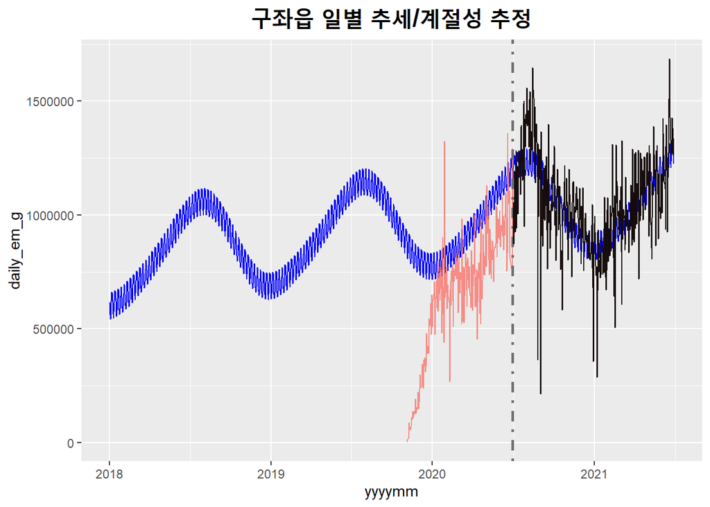

```r
goojwa_fill_na[(all_n-364):all_n, ] %>% ggplot() +
  geom_line(data = goojwa_fill_na1, aes(x = yyyymm, y = daily_em_g), color = 'blue') +
  geom_line(data = goojwa_na_dong, aes(x = base_date, y = sum_em_g, color = 'red'), alpha = 0.8) +
  geom_vline(xintercept = goojwa_fill_na$yyyymm[all_n - n] %>% as.numeric(), linetype = 4, size = 1, color = 'gray44') +
  geom_line(aes(x = yyyymm, y = daily_em_g), alpha = 0.9) +
  labs(title = "구좌읍 일별 추세/계절성 추정") +
  theme(plot.title = element_text(face = "bold", size = 18, hjust = 0.5), legend.position = "none")
```

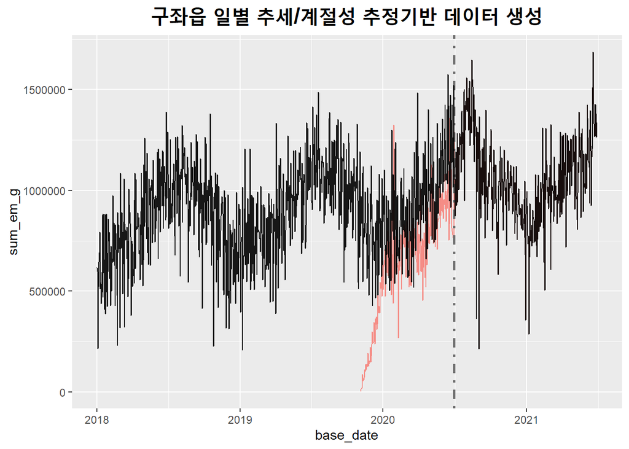

```r
goojwa_fill_na %>% ggplot() +
  geom_line(data = goojwa_na_dong, aes(x = base_date, y = sum_em_g, color = 'red'), alpha = 0.8) +
  geom_vline(xintercept = goojwa_fill_na$yyyymm[all_n - n] %>% as.numeric(), linetype = 4, size = 1, color = 'gray44') +
  geom_line(aes(x = yyyymm, y = daily_em_g), alpha = 0.9) +
  labs(title = "구좌읍 일별 추세/계절성 추정기반 데이터 생성") +
  theme(plot.title = element_text(face = "bold", size = 18, hjust = 0.5), legend.position = "none")
```

다음으로 나올 애월읍, 조천읍, 한경면, 한림읍 또한 동일한 방식이니, 추가적인 설명은 생략하겠습니다.

#### 애월읍

```r
aeweol_na_dong = daily_raw_data %>% filter(emd_nm == '애월읍')
aeweol_obs_vec = aeweol_na_dong[aeweol_na_dong$base_date >= as.Date('2020-07-01'), 'sum_em_g'] %>% unlist()

est_aeweol = lm(aeweol_obs_vec[365:1] ~ 1 + t + costerm1 + sinterm1 + costerm2 + sinterm2 + costerm3 + sinterm3)
sd_aeweol = ((est_aeweol$residuals^2 %>% sum) / n) %>% sqrt
est_aeweol_coef = est_aeweol$coefficients

y_time_seq = est_aeweol_coef[1] + est_aeweol_coef[2]*time_seq +
  est_aeweol_coef[3]*cos(m1*2*pi/all_n * time_seq) + est_aeweol_coef[4]*sin(m1*2*pi/all_n * time_seq) +
  est_aeweol_coef[5]*cos(m2*2*pi/all_n * time_seq) + est_aeweol_coef[6]*sin(m2*2*pi/all_n * time_seq) +
  est_aeweol_coef[7]*cos(m3*2*pi/all_n * time_seq) + est_aeweol_coef[8]*sin(m3*2*pi/all_n * time_seq) + rnorm(all_n, 0, sd_aeweol)

rev_aeweol = c(aeweol_obs_vec[365:1], y_time_seq[366:all_n])
aeweol_fill_na = data.frame(daily_date_time, '애월읍', rev_aeweol[all_n:1])
colnames(aeweol_fill_na) = c('yyyymm', 'emd_nm', 'daily_em_g')
```

#### 조천읍

조천읍, 한경면, 한림읍의 경우, 추정한 추세를 포함할 경우, 초기 관측치가 음수로 생성되거나 지나치게 크게 생성되는 경우가 있었습니다. 따라서 추세는 추정하고, 이를 데이터 생성시에는 포함시키지 않는 방식으로 진행하였습니다.

```r
chocheon_na_dong = daily_raw_data %>% filter(emd_nm == '조천읍')
chocheon_obs_vec = chocheon_na_dong[chocheon_na_dong$base_date >= as.Date('2020-07-01'), 'sum_em_g'] %>% unlist()

est_chocheon = lm(chocheon_obs_vec[365:1] ~ 1 + t + costerm1 + sinterm1 + costerm2 + sinterm2 + costerm3 + sinterm3)
sd_chocheon = ((est_chocheon$residuals^2 %>% sum) / n) %>% sqrt
est_chocheon_coef = est_chocheon$coefficients

y_time_seq = est_chocheon_coef[1] + #est_chocheon_coef[2]*time_seq +
  est_chocheon_coef[3]*cos(m1*2*pi/all_n * time_seq) + est_chocheon_coef[4]*sin(m1*2*pi/all_n * time_seq) +
  est_chocheon_coef[5]*cos(m2*2*pi/all_n * time_seq) + est_chocheon_coef[6]*sin(m2*2*pi/all_n * time_seq) +
  est_chocheon_coef[7]*cos(m3*2*pi/all_n * time_seq) + est_chocheon_coef[8]*sin(m3*2*pi/all_n * time_seq) + rnorm(all_n, 0, sd_chocheon)

rev_chocheon = c(chocheon_obs_vec[365:1], y_time_seq[366:all_n])
chocheon_fill_na = data.frame(daily_date_time, '조천읍', rev_chocheon[all_n:1])
colnames(chocheon_fill_na) = c('yyyymm', 'emd_nm', 'daily_em_g')
```

#### 한경면

```r
hangyeong_na_dong = daily_raw_data %>% filter(emd_nm == '한경면')
hangyeong_obs_vec = hangyeong_na_dong[hangyeong_na_dong$base_date >= as.Date('2020-07-01'), 'sum_em_g'] %>% unlist()

est_hangyeong = lm(hangyeong_obs_vec[365:1] ~ 1 + t + costerm1 + sinterm1 + costerm2 + sinterm2 + costerm3 + sinterm3)
sd_hangyeong = ((est_hangyeong$residuals^2 %>% sum) / n) %>% sqrt
est_hangyeong_coef = est_hangyeong$coefficients

y_time_seq = est_hangyeong_coef[1] + #est_hangyeong_coef[2]*time_seq +
  est_hangyeong_coef[3]*cos(m1*2*pi/all_n * time_seq) + est_hangyeong_coef[4]*sin(m1*2*pi/all_n * time_seq) +
  est_hangyeong_coef[5]*cos(m2*2*pi/all_n * time_seq) + est_hangyeong_coef[6]*sin(m2*2*pi/all_n * time_seq) +
  est_hangyeong_coef[7]*cos(m3*2*pi/all_n * time_seq) + est_hangyeong_coef[8]*sin(m3*2*pi/all_n * time_seq) + rnorm(all_n, 0, sd_hangyeong)

rev_hangyeong = c(hangyeong_obs_vec[365:1], y_time_seq[366:all_n])
hangyeong_fill_na = data.frame(daily_date_time, '한경면', rev_hangyeong[all_n:1])
colnames(hangyeong_fill_na) = c('yyyymm', 'emd_nm', 'daily_em_g')
```

#### 한림읍

```r
hanrim_na_dong = daily_raw_data %>% filter(emd_nm == '한림읍')
hanrim_obs_vec = hanrim_na_dong[hanrim_na_dong$base_date >= as.Date('2020-07-01'), 'sum_em_g'] %>% unlist()

est_hanrim = lm(hanrim_obs_vec[365:1] ~ 1 + t + costerm1 + sinterm1 + costerm2 + sinterm2 + costerm3 + sinterm3)
sd_hanrim = ((est_hanrim$residuals^2 %>% sum) / n) %>% sqrt
est_hanrim_coef = est_hanrim$coefficients

y_time_seq = est_hanrim_coef[1] + #est_hanrim_coef[2]*time_seq +
  est_hanrim_coef[3]*cos(m1*2*pi/all_n * time_seq) + est_hanrim_coef[4]*sin(m1*2*pi/all_n * time_seq) +
  est_hanrim_coef[5]*cos(m2*2*pi/all_n * time_seq) + est_hanrim_coef[6]*sin(m2*2*pi/all_n * time_seq) +
  est_hanrim_coef[7]*cos(m3*2*pi/all_n * time_seq) + est_hanrim_coef[8]*sin(m3*2*pi/all_n * time_seq) + rnorm(all_n, 0, sd_hanrim)

rev_hanrim = c(hanrim_obs_vec[365:1], y_time_seq[366:all_n])
hanrim_fill_na = data.frame(daily_date_time, '한림읍', rev_hanrim[all_n:1])
colnames(hanrim_fill_na) = c('yyyymm', 'emd_nm', 'daily_em_g')
```

### 1.2.2 서귀포시 대천동 외 10개 행정동

19년 초반에 많은 기기들에서 유사한 패턴으로 결측이 발생했습니다. 이는 서귀포시에서 19년에 기기들에 대해 교체작업을 시행했기 때문에 발생한 현상입니다. 이 패턴에 속하는 행정동은 대천동, 남원읍, 대륜동, 동홍동, 서홍동, 송산동, 예래동, 정방동, 중문동, 중앙동, 천지동입니다. 해당 행정동들은 결측이 발생한 부분을 제외한 데이터들로 회귀를 통해 추세와 계절성을 추정합니다. 추정된 회귀식을 바탕으로 이상치를 대체하는 데이터를 생성합니다.

더불어 대부분의 행정동에서 2020년 10월 23일에 결측이 존재했습니다. 이는 실제로 그날 모든 행정동이 쓰레기를 버리지 않았다기보다는, 데이터 수집상의 문제가 있었던 것으로 추측됩니다. 해당 부분의 결측은 **Spline Interpolation(스플라인 보간법)**을 통해 해결했습니다. 길이가 매우 짧기 때문에, 주위 관측치의 정보를 통해 충분히 다룰 수 있다고 보았습니다. 회귀로 추정 후 데이터를 생성하는 부분 이외의 결측은 모두 길이가 매우 짧기 때문에 스플라인을 통해 보간을 진행했습니다.

대천동에 대한 전처리 과정은 이전에 구좌읍의 경우와 매우 유사합니다. 결과를 시각화하고, 행정동별로 특이사항이 없는 경우에는 자세한 설명은 생략하겠습니다.

#### 대천동

```r
make_na_index = daily_date_time >= as.Date('2019-01-01') & daily_date_time <= as.Date('2019-05-30')
n = daily_date_time %>% unlist() %>% length() - make_na_index %>% sum
t = c(1:365, 516:all_n) # 이상치 부분을 제외
m1 = all_n/7; m2 = all_n/182.5; m3 = all_n/365
costerm1 = cos(m1*2*pi/all_n*t); sinterm1 = sin(m1*2*pi/all_n*t); costerm2 = cos(m2*2*pi/all_n*t); sinterm2 = sin(m2*2*pi/all_n*t)
costerm3 = cos(m3*2*pi/all_n*t); sinterm3 = sin(m3*2*pi/all_n*t)

daecheon_na_dong = daily_raw_data %>% filter(emd_nm == '대천동') %>% select(-emd_nm)
daecheon_spline = data.frame(daily_date_time, na_interpolation(daecheon_na_dong$sum_em_g, option = 'spline')) #스플라인 보간 자동적으로 진행
colnames(daecheon_spline) = c('yyyymm', 'daily_em_g')

est_daecheon = lm(daecheon_spline$daily_em_g[!make_na_index] ~ 1 + t + costerm1 + sinterm1 + costerm2 + sinterm2 + costerm3 + sinterm3)
sd_daecheon = ((est_daecheon$residuals^2 %>% sum) / n) %>% sqrt
est_daecheon_coef = est_daecheon$coefficients

y_time_seq = est_daecheon_coef[1] + est_daecheon_coef[2]*time_seq +
  est_daecheon_coef[3]*cos(m1*2*pi/all_n * time_seq) + est_daecheon_coef[4]*sin(m1*2*pi/all_n * time_seq) +
  est_daecheon_coef[5]*cos(m2*2*pi/all_n * time_seq) + est_daecheon_coef[6]*sin(m2*2*pi/all_n * time_seq) +
  est_daecheon_coef[7]*cos(m3*2*pi/all_n * time_seq) + est_daecheon_coef[8]*sin(m3*2*pi/all_n * time_seq) + rnorm(all_n, 0, sd_daecheon)
daecheon_em_g = c(daecheon_spline[1:365, 'daily_em_g'], y_time_seq[366:515], daecheon_spline[516:all_n, 'daily_em_g'])
daecheon_fill_na = data.frame(daily_date_time, '대천동', daecheon_em_g)
colnames(daecheon_fill_na) = c('yyyymm', 'emd_nm', 'daily_em_g')

# 추세/계절성 시각화용
y_time_seq1 = est_daecheon_coef[1] + est_daecheon_coef[2]*time_seq +
  est_daecheon_coef[3]*cos(m1*2*pi/all_n * time_seq) + est_daecheon_coef[4]*sin(m1*2*pi/all_n * time_seq) +
  est_daecheon_coef[5]*cos(m2*2*pi/all_n * time_seq) + est_daecheon_coef[6]*sin(m2*2*pi/all_n * time_seq) +
  est_daecheon_coef[7]*cos(m3*2*pi/all_n * time_seq) + est_daecheon_coef[8]*sin(m3*2*pi/all_n * time_seq)
daecheon_fill_na1 = data.frame(daily_date_time, '대천동', y_time_seq1)
colnames(daecheon_fill_na1) = c('yyyymm', 'emd_nm', 'daily_em_g')
```

대천동의 결과를 시각화하면 다음과 같습니다.

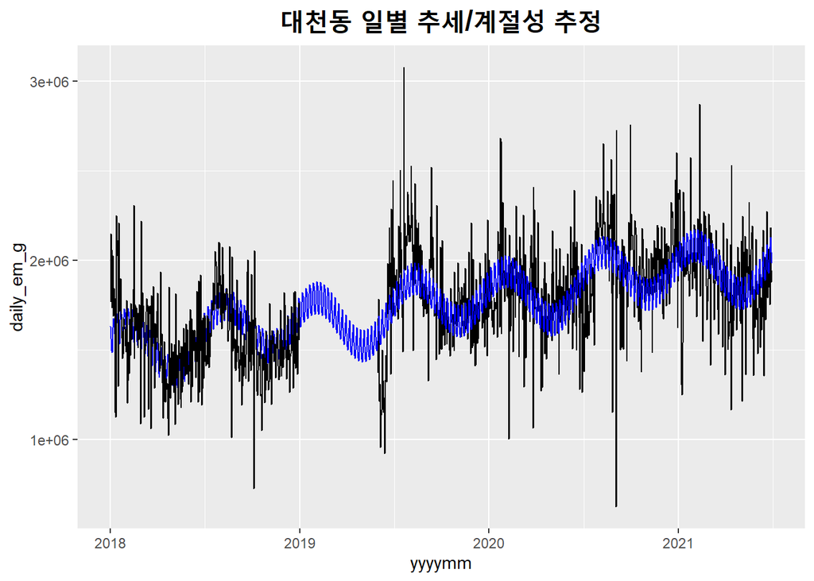

```r
daecheon_fill_na[1:365, ] %>% ggplot() +
  geom_line(data = daecheon_fill_na[516:all_n, ], aes(x = yyyymm, y = daily_em_g)) +
  geom_line(data = daecheon_fill_na1, aes(x = yyyymm, y = daily_em_g), color = 'blue') +
  geom_line(aes(x = yyyymm, y = daily_em_g)) +
  labs(title = "대천동 일별 추세/계절성 추정") +
  theme(plot.title = element_text(face = "bold", size = 18, hjust = 0.5))
```

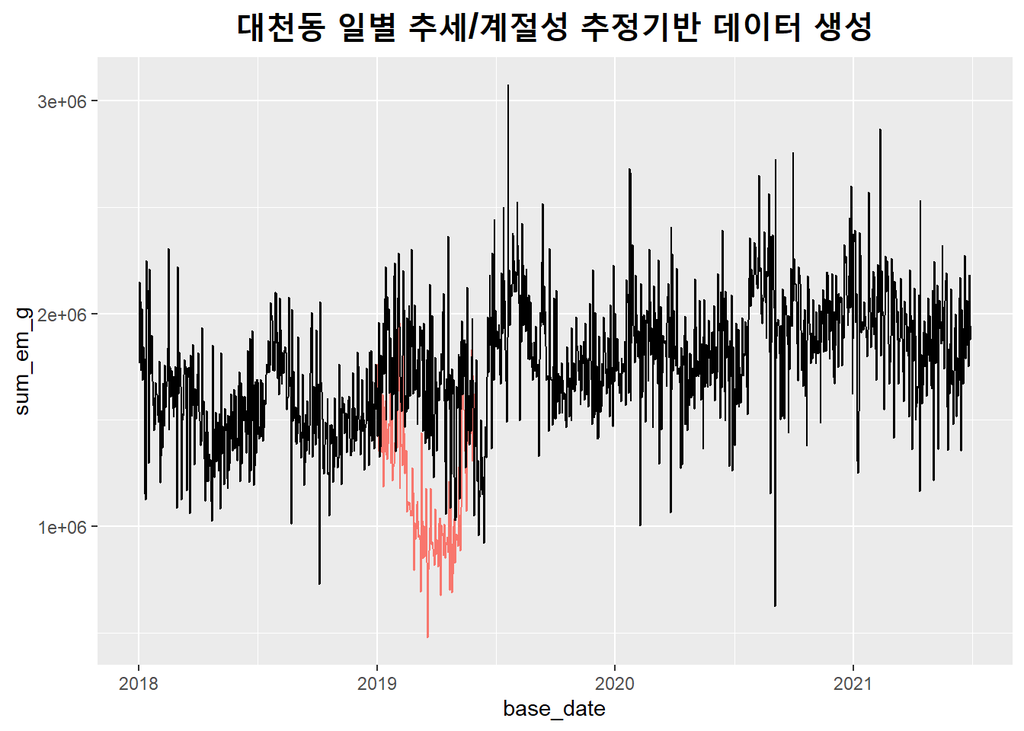

```r
daecheon_fill_na %>% ggplot() +
  geom_line(data = daecheon_na_dong[366:515, ], aes(x = base_date, y = sum_em_g, color = 'red')) +
  geom_line(aes(x = yyyymm, y = daily_em_g)) +
  labs(title = "대천동 일별 추세/계절성 추정기반 데이터 생성") +
  theme(plot.title = element_text(face = "bold", size = 18, hjust = 0.5), legend.position = "none")
```

이후 행정동들도 동일한 방식으로 전처리를 시행했습니다.

#### 남원읍

```r
make_na_index = daily_date_time >= as.Date('2019-01-01') & daily_date_time <= as.Date('2019-05-20')
n = daily_date_time %>% unlist() %>% length() - make_na_index %>% sum
t = c(1:365, 506:all_n)
m1 = all_n/7; m2 = all_n/182.5; m3 = all_n/365
costerm1 = cos(m1*2*pi/all_n*t); sinterm1 = sin(m1*2*pi/all_n*t); costerm2 = cos(m2*2*pi/all_n*t); sinterm2 = sin(m2*2*pi/all_n*t)
costerm3 = cos(m3*2*pi/all_n*t); sinterm3 = sin(m3*2*pi/all_n*t)

namwon_na_dong = daily_raw_data %>% filter(emd_nm == '남원읍') %>% select(-emd_nm)
namwon_spline = data.frame(daily_date_time, na_interpolation(namwon_na_dong$sum_em_g, option = 'spline'))
colnames(namwon_spline) = c('yyyymm', 'daily_em_g')

est_namwon = lm(namwon_spline$daily_em_g[!make_na_index] ~ 1 + t + costerm1 + sinterm1 + costerm2 + sinterm2 + costerm3 + sinterm3)
sd_namwon = ((est_namwon$residuals^2 %>% sum) / all_n) %>% sqrt
est_namwon_coef = est_namwon$coefficients

y_time_seq = est_namwon_coef[1] + est_namwon_coef[2]*time_seq +
  est_namwon_coef[3]*cos(m1*2*pi/all_n * time_seq) + est_namwon_coef[4]*sin(m1*2*pi/all_n * time_seq) +
  est_namwon_coef[5]*cos(m2*2*pi/all_n * time_seq) + est_namwon_coef[6]*sin(m2*2*pi/all_n * time_seq) +
  est_namwon_coef[7]*cos(m3*2*pi/all_n * time_seq) + est_namwon_coef[8]*sin(m2*2*pi/all_n * time_seq) + rnorm(all_n, 0, sd_namwon)

namwon_em_g = c(namwon_spline[1:365, 'daily_em_g'], y_time_seq[366:505], namwon_spline[506:all_n, 'daily_em_g'])
namwon_fill_na = data.frame(daily_date_time, '남원읍', namwon_em_g)
colnames(namwon_fill_na) = c('yyyymm', 'emd_nm', 'daily_em_g')
```

#### 대륜동

```r
make_na_index = daily_date_time >= as.Date('2019-02-01') & daily_date_time <= as.Date('2019-05-30')
n = daily_date_time %>% unlist() %>% length() - make_na_index %>% sum
t = c(1:396, 516:all_n)
m1 = all_n/7; m2 = all_n/182.5; m3 = all_n/365
costerm1 = cos(m1*2*pi/all_n*t); sinterm1 = sin(m1*2*pi/all_n*t); costerm2 = cos(m2*2*pi/all_n*t); sinterm2 = sin(m2*2*pi/all_n*t)
costerm3 = cos(m3*2*pi/all_n*t); sinterm3 = sin(m3*2*pi/all_n*t)

daeryun_na_dong = daily_raw_data %>% filter(emd_nm == '대륜동') %>% select(-emd_nm)
daeryun_spline = data.frame(daily_date_time, na_interpolation(daeryun_na_dong$sum_em_g, option = 'spline'))
colnames(daeryun_spline) = c('yyyymm', 'daily_em_g')

est_daeryun = lm(daeryun_spline$daily_em_g[!make_na_index] ~ 1 + t + costerm1 + sinterm1 + costerm2 + sinterm2 + costerm3 + sinterm3)
sd_daeryun = ((est_daeryun$residuals^2 %>% sum) / n) %>% sqrt
est_daeryun_coef = est_daeryun$coefficients

y_time_seq = est_daeryun_coef[1] + est_daeryun_coef[2]*time_seq +
  est_daeryun_coef[3]*cos(m1*2*pi/all_n * time_seq) + est_daeryun_coef[4]*sin(m1*2*pi/all_n * time_seq) +
  est_daeryun_coef[5]*cos(m2*2*pi/all_n * time_seq) + est_daeryun_coef[6]*sin(m2*2*pi/all_n * time_seq) +
  est_daeryun_coef[7]*cos(m3*2*pi/all_n * time_seq) + est_daeryun_coef[8]*sin(m3*2*pi/all_n * time_seq) + rnorm(all_n, 0, sd_daeryun)
daeryun_em_g = c(daeryun_spline[1:396, 'daily_em_g'], y_time_seq[397:515], daeryun_spline[516:all_n, 'daily_em_g'])
daeryun_fill_na = data.frame(daily_date_time, '대륜동', daeryun_em_g)
colnames(daeryun_fill_na) = c('yyyymm', 'emd_nm', 'daily_em_g')
```

#### 동홍동

동홍동의 경우 추가적으로 21년 5월 20일부터 6월 20일의 데이터에서 관측지점별로 연속적인 결측이 발견되었습니다. 해당 경향이 다른 행정동들에서 산발적으로 나타나기 때문에, 추가적으로 이상치 대체작업을 진행하였습니다.

```r
make_na_index = (daily_date_time >= as.Date('2019-01-01') & daily_date_time <= as.Date('2019-05-30')) |
  (daily_date_time >= as.Date('2021-05-20') & daily_date_time <= as.Date('2021-06-20'))
n = daily_date_time %>% unlist() %>% length() - make_na_index %>% sum
t = c(1:365, 516:1235, 1268:all_n)
m1 = all_n/7; m2 = all_n/182.5; m3 = all_n/365
costerm1 = cos(m1*2*pi/all_n*t); sinterm1 = sin(m1*2*pi/all_n*t); costerm2 = cos(m2*2*pi/all_n*t); sinterm2 = sin(m2*2*pi/all_n*t)
costerm3 = cos(m3*2*pi/all_n*t); sinterm3 = sin(m3*2*pi/all_n*t)

donghong_na_dong = daily_raw_data %>% filter(emd_nm == '동홍동') %>% select(-emd_nm)
donghong_spline = data.frame(daily_date_time, na_interpolation(donghong_na_dong$sum_em_g, option = 'spline'))
colnames(donghong_spline) = c('yyyymm', 'daily_em_g')

est_donghong = lm(donghong_spline$daily_em_g[!make_na_index] ~ 1 + t + costerm1 + sinterm1 + costerm2 + sinterm2 + costerm3 + sinterm3)
sd_donghong = ((est_donghong$residuals^2 %>% sum) / n) %>% sqrt
est_donghong_coef = est_donghong$coefficients

y_time_seq = est_donghong_coef[1] + est_donghong_coef[2]*time_seq +
  est_donghong_coef[3]*cos(m1*2*pi/all_n * time_seq) + est_donghong_coef[4]*sin(m1*2*pi/all_n * time_seq) +
  est_donghong_coef[5]*cos(m2*2*pi/all_n * time_seq) + est_donghong_coef[6]*sin(m2*2*pi/all_n * time_seq) +
  est_donghong_coef[7]*cos(m3*2*pi/all_n * time_seq) + est_donghong_coef[8]*sin(m3*2*pi/all_n * time_seq) + rnorm(all_n, 0, sd_donghong)
donghong_em_g = c(donghong_spline[1:365, 'daily_em_g'], y_time_seq[366:515], donghong_spline[516:1235, 'daily_em_g'],
                  y_time_seq[1236:1267], donghong_spline[1268:all_n, 'daily_em_g'])
donghong_fill_na = data.frame(daily_date_time, '동홍동', donghong_em_g)
colnames(donghong_fill_na) = c('yyyymm', 'emd_nm', 'daily_em_g')
```

동홍동의 경우 추가적인 이상치 대체과정으로 처음 등장하기 때문에, 추가적인 시각화를 진행하겠습니다.

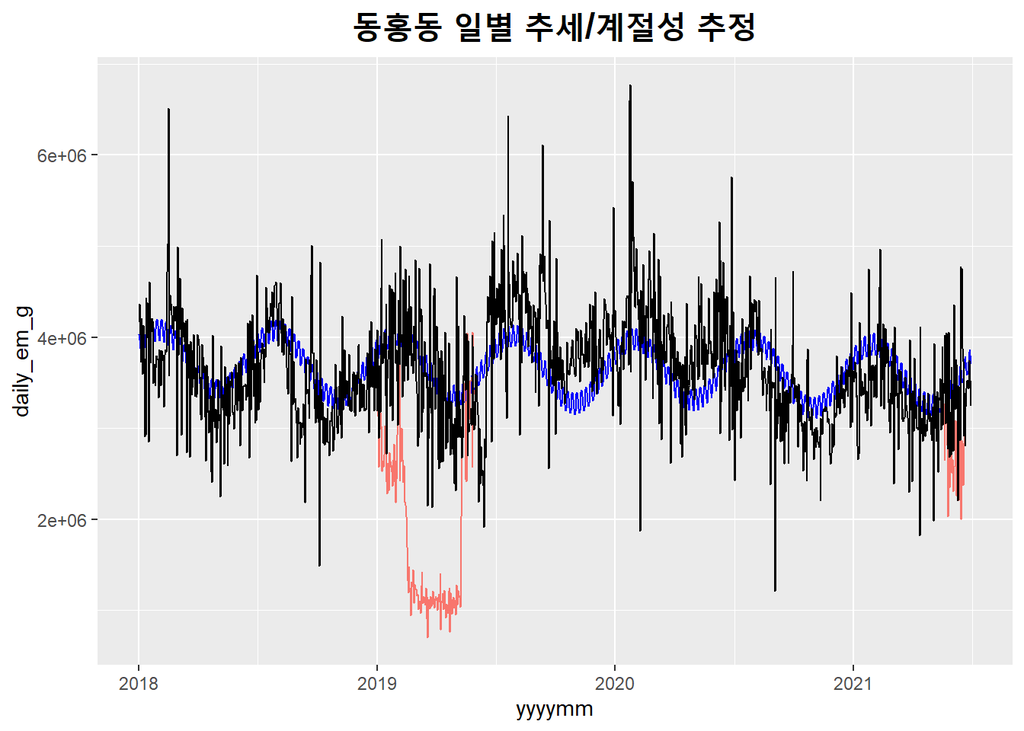

```r
y_time_seq1 = est_donghong_coef[1] + est_donghong_coef[2]*time_seq +
  est_donghong_coef[3]*cos(m1*2*pi/all_n * time_seq) + est_donghong_coef[4]*sin(m1*2*pi/all_n * time_seq) +
  est_donghong_coef[5]*cos(m2*2*pi/all_n * time_seq) + est_donghong_coef[6]*sin(m2*2*pi/all_n * time_seq) +
  est_donghong_coef[7]*cos(m3*2*pi/all_n * time_seq) + est_donghong_coef[8]*sin(m3*2*pi/all_n * time_seq)
donghong_fill_na1 = data.frame(daily_date_time, '동홍동', y_time_seq1)
colnames(donghong_fill_na1) = c('yyyymm', 'emd_nm', 'daily_em_g')

donghong_fill_na %>% ggplot() +
  geom_line(data = donghong_fill_na1, aes(x = yyyymm, y = daily_em_g), color = 'blue') +
  geom_line(data = donghong_na_dong[366:515, ], aes(x = base_date, y = sum_em_g, color = 'red')) +
  geom_line(data = donghong_na_dong[1236:1267, ], aes(x = base_date, y = sum_em_g, color = 'red')) +
  geom_line(aes(x = yyyymm, y = daily_em_g)) +
  labs(title = "동홍동 일별 추세/계절성 추정") +
  theme(plot.title = element_text(face = "bold", size = 18, hjust = 0.5), legend.position = "none")
```

### 서홍동

서홍동의 경우에도 21년 5월부터 6월 사이 동홍동과 비슷한 현상이 발생했습니다.

```r
make_na_index = (daily_date_time >= as.Date('2019-01-01') & daily_date_time <= as.Date('2019-05-20')) |
  (daily_date_time >= as.Date('2021-05-20') & daily_date_time <= as.Date('2021-06-20'))
n = daily_date_time %>% unlist() %>% length() - make_na_index %>% sum
t = c(1:365, 506:1235, 1268:all_n)
m1 = all_n/7; m2 = all_n/182.5; m3 = all_n/365
costerm1 = cos(m1*2*pi/all_n*t); sinterm1 = sin(m1*2*pi/all_n*t); costerm2 = cos(m2*2*pi/all_n*t); sinterm2 = sin(m2*2*pi/all_n*t)
costerm3 = cos(m3*2*pi/all_n*t); sinterm3 = sin(m3*2*pi/all_n*t)

seohong_na_dong = daily_raw_data %>% filter(emd_nm == '서홍동') %>% select(-emd_nm)
seohong_spline = data.frame(daily_date_time, na_interpolation(seohong_na_dong$sum_em_g, option = 'spline'))
colnames(seohong_spline) = c('yyyymm', 'daily_em_g')

est_seohong = lm(seohong_spline$daily_em_g[!make_na_index] ~ 1 + t + costerm1 + sinterm1 + costerm2 + sinterm2 + costerm3 + sinterm3)
sd_seohong = ((est_seohong$residuals^2 %>% sum) / n) %>% sqrt
est_seohong_coef = est_seohong$coefficients

y_time_seq = est_seohong_coef[1] + est_seohong_coef[2]*time_seq +
  est_seohong_coef[3]*cos(m1*2*pi/all_n * time_seq) + est_seohong_coef[4]*sin(m1*2*pi/all_n * time_seq) +
  est_seohong_coef[5]*cos(m2*2*pi/all_n * time_seq) + est_seohong_coef[6]*sin(m2*2*pi/all_n * time_seq) +
  est_seohong_coef[7]*cos(m3*2*pi/all_n * time_seq) + est_seohong_coef[7]*sin(m3*2*pi/all_n * time_seq) + rnorm(all_n, 0, sd_seohong)
seohong_em_g = c(seohong_spline[1:365, 'daily_em_g'], y_time_seq[366:505], seohong_spline[506:1235, 'daily_em_g'],
                 y_time_seq[1236:1267], seohong_spline[1268:all_n, 'daily_em_g'])
seohong_fill_na = data.frame(daily_date_time, '서홍동', seohong_em_g)
colnames(seohong_fill_na) = c('yyyymm', 'emd_nm', 'daily_em_g')
```

#### 송산동

```r
make_na_index = daily_date_time >= as.Date('2019-02-10') & daily_date_time <= as.Date('2019-05-11')
n = daily_date_time %>% unlist() %>% length() - make_na_index %>% sum
t = c(1:405, 497:all_n)
m1 = all_n/7; m2 = all_n/182.5; m3 = all_n/365
costerm1 = cos(m1*2*pi/all_n*t); sinterm1 = sin(m1*2*pi/all_n*t); costerm2 = cos(m2*2*pi/all_n*t); sinterm2 = sin(m2*2*pi/all_n*t)
costerm3 = cos(m3*2*pi/all_n*t); sinterm3 = sin(m3*2*pi/all_n*t)

songsan_na_dong = daily_raw_data %>% filter(emd_nm == '송산동') %>% select(-emd_nm)
songsan_spline = data.frame(daily_date_time, na_interpolation(songsan_na_dong$sum_em_g, option = 'spline'))
colnames(songsan_spline) = c('yyyymm', 'daily_em_g')

est_songsan = lm(songsan_spline$daily_em_g[!make_na_index] ~ 1 + t + costerm1 + sinterm1 + costerm2 + sinterm2 + costerm3 + sinterm3)
sd_songsan = ((est_songsan$residuals^2 %>% sum) / n) %>% sqrt
est_songsan_coef = est_songsan$coefficients

y_time_seq = est_songsan_coef[1] + est_songsan_coef[2]*time_seq +
  est_songsan_coef[3]*cos(m1*2*pi/all_n * time_seq) + est_songsan_coef[4]*sin(m1*2*pi/all_n * time_seq) +
  est_songsan_coef[5]*cos(m2*2*pi/all_n * time_seq) + est_songsan_coef[6]*sin(m2*2*pi/all_n * time_seq) +
  est_songsan_coef[7]*cos(m3*2*pi/all_n * time_seq) + est_songsan_coef[8]*sin(m3*2*pi/all_n * time_seq) + rnorm(all_n, 0, sd_songsan)
songsan_em_g = c(songsan_spline[1:405, 'daily_em_g'], y_time_seq[406:496], songsan_spline[497:all_n, 'daily_em_g'])
songsan_fill_na = data.frame(daily_date_time, '송산동', songsan_em_g)
colnames(songsan_fill_na) = c('yyyymm', 'emd_nm', 'daily_em_g')
```

#### 예래동

```r
make_na_index = daily_date_time >= as.Date('2019-02-11') & daily_date_time <= as.Date('2019-05-30')
n = daily_date_time %>% unlist() %>% length() - make_na_index %>% sum
t = c(1:406, 516:all_n)
m1 = all_n/7; m2 = all_n/182.5; m3 = all_n/365
costerm1 = cos(m1*2*pi/all_n*t); sinterm1 = sin(m1*2*pi/all_n*t); costerm2 = cos(m2*2*pi/all_n*t); sinterm2 = sin(m2*2*pi/all_n*t)
costerm3 = cos(m3*2*pi/all_n*t); sinterm3 = sin(m3*2*pi/all_n*t)

yerae_na_dong = daily_raw_data %>% filter(emd_nm == '예래동') %>% select(-emd_nm)
yerae_spline = data.frame(daily_date_time, na_interpolation(yerae_na_dong$sum_em_g, option = 'spline'))
colnames(yerae_spline) = c('yyyymm', 'daily_em_g')

est_yerae = lm(yerae_spline$daily_em_g[!make_na_index] ~ 1 + t + costerm1 + sinterm1 + costerm2 + sinterm2 + costerm3 + sinterm3)
sd_yerae = ((est_yerae$residuals^2 %>% sum) / n) %>% sqrt
est_yerae_coef = est_yerae$coefficients

y_time_seq = est_yerae_coef[1] + est_yerae_coef[2]*time_seq +
  est_yerae_coef[3]*cos(m1*2*pi/all_n * time_seq) + est_yerae_coef[4]*sin(m1*2*pi/all_n * time_seq) +
  est_yerae_coef[5]*cos(m2*2*pi/all_n * time_seq) + est_yerae_coef[6]*sin(m2*2*pi/all_n * time_seq) +
  est_yerae_coef[7]*cos(m3*2*pi/all_n * time_seq) + est_yerae_coef[8]*sin(m3*2*pi/all_n * time_seq) + rnorm(all_n, 0, sd_yerae)
yerae_em_g = c(yerae_spline[1:406, 'daily_em_g'], y_time_seq[407:515], yerae_spline[516:all_n, 'daily_em_g'])
yerae_fill_na = data.frame(daily_date_time, '예래동', yerae_em_g)
colnames(yerae_fill_na) = c('yyyymm', 'emd_nm', 'daily_em_g')
```

### 정방동

정방동의 경우, 20년 7월 기간에도 연속적인 결측이 발생했습니다. 해당 부분도 대체를 진행했습니다.

```r
make_na_index = (daily_date_time >= as.Date('2019-01-01') & daily_date_time <= as.Date('2019-05-30')) |
  (daily_date_time >= as.Date('2020-07-01') & daily_date_time <= as.Date('2020-07-31'))
n = daily_date_time %>% unlist() %>% length() - make_na_index %>% sum
t = c(1:365, 516:912, 944:all_n)
m1 = all_n/7; m2 = all_n/182.5; m3 = all_n/365
costerm1 = cos(m1*2*pi/all_n*t); sinterm1 = sin(m1*2*pi/all_n*t); costerm2 = cos(m2*2*pi/all_n*t); sinterm2 = sin(m2*2*pi/all_n*t)
costerm3 = cos(m3*2*pi/all_n*t); sinterm3 = sin(m3*2*pi/all_n*t)

jeongbang_na_dong = daily_raw_data %>% filter(emd_nm == '정방동') %>% select(-emd_nm)
jeongbang_spline = data.frame(daily_date_time, na_interpolation(jeongbang_na_dong$sum_em_g, option = 'spline'))
colnames(jeongbang_spline) = c('yyyymm', 'daily_em_g')

est_jeongbang = lm(jeongbang_spline$daily_em_g[!make_na_index] ~ 1 + t + costerm1 + sinterm1 + costerm2 + sinterm2 + costerm3 + sinterm3)
sd_jeongbang = ((est_jeongbang$residuals^2 %>% sum) / n) %>% sqrt
est_jeongbang_coef = est_jeongbang$coefficients

y_time_seq = est_jeongbang_coef[1] + est_jeongbang_coef[2]*time_seq +
  est_jeongbang_coef[3]*cos(m1*2*pi/all_n * time_seq) + est_jeongbang_coef[4]*sin(m1*2*pi/all_n * time_seq) +
  est_jeongbang_coef[5]*cos(m2*2*pi/all_n * time_seq) + est_jeongbang_coef[6]*sin(m2*2*pi/all_n * time_seq) +
  est_jeongbang_coef[7]*cos(m3*2*pi/all_n * time_seq) + est_jeongbang_coef[8]*sin(m3*2*pi/all_n * time_seq) + rnorm(all_n, 0, sd_jeongbang)
jeongbang_em_g = c(jeongbang_spline[1:365, 'daily_em_g'], y_time_seq[366:515], jeongbang_spline[516:912, 'daily_em_g'],
                   y_time_seq[913:943], jeongbang_spline[944:all_n, 'daily_em_g'])
jeongbang_fill_na = data.frame(daily_date_time, '정방동', jeongbang_em_g)
colnames(jeongbang_fill_na) = c('yyyymm', 'emd_nm', 'daily_em_g')
```

#### 중문동

중문동의 경우에도 정방동과 비슷한 패턴의 결측이 발생했습니다.

```r
make_na_index = (daily_date_time >= as.Date('2019-02-01') & daily_date_time <= as.Date('2019-05-30')) |
  (daily_date_time >= as.Date('2020-07-01') & daily_date_time <= as.Date('2020-07-15'))
n = daily_date_time %>% unlist() %>% length() - make_na_index %>% sum
t = c(1:396, 516:912, 928:all_n)
m1 = all_n/7; m2 = all_n/182.5; m3 = all_n/365
costerm1 = cos(m1*2*pi/all_n*t); sinterm1 = sin(m1*2*pi/all_n*t); costerm2 = cos(m2*2*pi/all_n*t); sinterm2 = sin(m2*2*pi/all_n*t)
costerm3 = cos(m3*2*pi/all_n*t); sinterm3 = sin(m3*2*pi/all_n*t)

joongmoon_na_dong = daily_raw_data %>% filter(emd_nm == '중문동') %>% select(-emd_nm)
joongmoon_spline = data.frame(daily_date_time, na_interpolation(joongmoon_na_dong$sum_em_g, option = 'spline'))
colnames(joongmoon_spline) = c('yyyymm', 'daily_em_g')

est_joongmoon = lm(joongmoon_spline$daily_em_g[!make_na_index] ~ 1 + t + costerm1 + sinterm1 + costerm2 + sinterm2 + costerm3 + sinterm3)
sd_joongmoon = ((est_joongmoon$residuals^2 %>% sum) / n) %>% sqrt
est_joongmoon_coef = est_joongmoon$coefficients

y_time_seq = est_joongmoon_coef[1] + est_joongmoon_coef[2]*time_seq +
  est_joongmoon_coef[3]*cos(m1*2*pi/all_n * time_seq) + est_joongmoon_coef[4]*sin(m1*2*pi/all_n * time_seq) +
  est_joongmoon_coef[5]*cos(m2*2*pi/all_n * time_seq) + est_joongmoon_coef[6]*sin(m2*2*pi/all_n * time_seq) +
  est_joongmoon_coef[7]*cos(m3*2*pi/all_n * time_seq) + est_joongmoon_coef[8]*sin(m3*2*pi/all_n * time_seq) + rnorm(all_n, 0, sd_joongmoon)
joongmoon_em_g = c(joongmoon_spline[1:396, 'daily_em_g'], y_time_seq[397:515], joongmoon_spline[516:912, 'daily_em_g'],
                   y_time_seq[913:927], joongmoon_spline[928:all_n, 'daily_em_g'])
joongmoon_fill_na = data.frame(daily_date_time, '중문동', joongmoon_em_g)
colnames(joongmoon_fill_na) = c('yyyymm', 'emd_nm', 'daily_em_g')
```

#### 중앙동

중앙동의 경우에도 정방동,중문동과 비슷한 패턴의 결측이 발생했습니다.

```r
make_na_index = (daily_date_time >= as.Date('2019-02-01') & daily_date_time <= as.Date('2019-06-20')) |
  (daily_date_time >= as.Date('2020-07-01') & daily_date_time <= as.Date('2020-07-15'))

n = daily_date_time %>% unlist() %>% length() - make_na_index %>% sum
t = c(1:396, 537:912, 928:all_n)
m1 = all_n/7; m2 = all_n/182.5; m3 = all_n/365
costerm1 = cos(m1*2*pi/all_n*t); sinterm1 = sin(m1*2*pi/all_n*t); costerm2 = cos(m2*2*pi/all_n*t); sinterm2 = sin(m2*2*pi/all_n*t)
costerm3 = cos(m3*2*pi/all_n*t); sinterm3 = sin(m3*2*pi/all_n*t)

joongang_na_dong = daily_raw_data %>% filter(emd_nm == '중앙동') %>% select(-emd_nm)
joongang_spline = data.frame(daily_date_time, na_interpolation(joongang_na_dong$sum_em_g, option = 'spline'))
colnames(joongang_spline) = c('yyyymm', 'daily_em_g')

est_joongang = lm(joongang_spline$daily_em_g[!make_na_index] ~ 1 + t + costerm1 + sinterm1 + costerm2 + sinterm2 + costerm3 + sinterm3)
sd_joongang = ((est_joongang$residuals^2 %>% sum) / n) %>% sqrt
est_joongang_coef = est_joongang$coefficients

y_time_seq = est_joongang_coef[1] + est_joongang_coef[2]*time_seq +
  est_joongang_coef[3]*cos(m1*2*pi/all_n * time_seq) + est_joongang_coef[4]*sin(m1*2*pi/all_n * time_seq) +
  est_joongang_coef[5]*cos(m2*2*pi/all_n * time_seq) + est_joongang_coef[6]*sin(m2*2*pi/all_n * time_seq) +
  est_joongang_coef[7]*cos(m3*2*pi/all_n * time_seq) + est_joongang_coef[8]*sin(m3*2*pi/all_n * time_seq) + rnorm(all_n, 0, sd_joongang)
joongang_em_g = c(joongang_spline[1:396, 'daily_em_g'], y_time_seq[397:536], joongang_spline[537:912, 'daily_em_g'],
                  y_time_seq[913:927], joongang_spline[928:all_n, 'daily_em_g'])
joongang_fill_na = data.frame(daily_date_time, '중앙동', joongang_em_g)
colnames(joongang_fill_na) = c('yyyymm', 'emd_nm', 'daily_em_g')
```

### 천지동

천지동의 경우에도 정방동, 중문동, 중앙동과 비슷한 패턴의 결측이 발생했습니다.

```r
make_na_index = (daily_date_time >= as.Date('2019-01-01') & daily_date_time <= as.Date('2019-05-20') |
                   (daily_date_time >= as.Date('2020-06-29') & daily_date_time <= as.Date('2020-07-25')))

n = daily_date_time %>% unlist() %>% length() - make_na_index %>% sum
t = c(1:365, 506:910, 938:all_n)
m1 = all_n/7; m2 = all_n/182.5; m3 = all_n/365
costerm1 = cos(m1*2*pi/all_n*t); sinterm1 = sin(m1*2*pi/all_n*t); costerm2 = cos(m2*2*pi/all_n*t); sinterm2 = sin(m2*2*pi/all_n*t)
costerm3 = cos(m3*2*pi/all_n*t); sinterm3 = sin(m3*2*pi/all_n*t)

cheonji_na_dong = daily_raw_data %>% filter(emd_nm == '천지동') %>% select(-emd_nm)
cheonji_spline = data.frame(daily_date_time, na_interpolation(cheonji_na_dong$sum_em_g, option = 'spline'))
colnames(cheonji_spline) = c('yyyymm', 'daily_em_g')

est_cheonji = lm(cheonji_spline$daily_em_g[!make_na_index] ~ 1 + t + costerm1 + sinterm1 + costerm2 + sinterm2 + costerm3 + sinterm3)
sd_cheonji = ((est_cheonji$residuals^2 %>% sum) / n) %>% sqrt
est_cheonji_coef = est_cheonji$coefficients

y_time_seq = est_cheonji_coef[1] + est_cheonji_coef[2]*time_seq +
  est_cheonji_coef[3]*cos(m1*2*pi/all_n * time_seq) + est_cheonji_coef[4]*sin(m1*2*pi/all_n * time_seq) +
  est_cheonji_coef[5]*cos(m2*2*pi/all_n * time_seq) + est_cheonji_coef[6]*sin(m2*2*pi/all_n * time_seq) +
  est_cheonji_coef[7]*cos(m3*2*pi/all_n * time_seq) + est_cheonji_coef[8]*sin(m3*2*pi/all_n * time_seq) + rnorm(all_n, 0, sd_cheonji)
cheonji_em_g = c(cheonji_spline[1:365, 'daily_em_g'], y_time_seq[366:505], cheonji_spline[506:910, 'daily_em_g'],
                 y_time_seq[911:937], cheonji_spline[938:all_n, 'daily_em_g'])
cheonji_fill_na = data.frame(daily_date_time, '천지동', cheonji_em_g)
colnames(cheonji_fill_na) = c('yyyymm', 'emd_nm', 'daily_em_g')
```

### 1.2.3 서귀포시 효돈동 외 5개 동

서귀포시의 효돈동, 영천동, 성산읍, 표선면, 안덕면, 대정읍은 모두 결측이 오래동안 지속된 행정동들입니다. 이전의 두 패턴들의 종합이라고 볼 수 있습니다. 관측기간 초반에는 해당 행정동 전역에 RFID 기기가 보급되지 않았던 것으로 추측됩니다. 따라서 모든기기가 관측을 시작한 날부터의 데이터를 정상 데이터로 가정하고, 그 앞부분의 데이터는 정상 데이터의 추세와 계절성을 통해 생성한 데이터로 대체합니다.

효돈동이 경우를 예시로 보고, 나머지 행정동에 대한 설명은 생략하겠습니다.

#### 효돈동

```r
n = all_n - 944 + 1
t = c(944:all_n) # for regression
m1 = n/7; m2 = n/182.5; m3 = n/365
costerm1 = cos(m1*2*pi/n*t); sinterm1 = sin(m1*2*pi/n*t); costerm2 = cos(m2*2*pi/n*t); sinterm2 = sin(m2*2*pi/n*t)
costerm3 = cos(m3*2*pi/n*t); sinterm3 = sin(m3*2*pi/n*t)

hyodon_na_dong = daily_raw_data %>% filter(emd_nm == '효돈동') %>% select(-emd_nm)
hyodon_spline = data.frame(daily_date_time, na_interpolation(hyodon_na_dong$sum_em_g, option = 'spline'))
colnames(hyodon_spline) = c('yyyymm', 'daily_em_g')

est_hyodon = lm(hyodon_spline$daily_em_g[944:all_n] ~ 1 + t + costerm1 + sinterm1 + costerm2 + sinterm2 + costerm3 + sinterm3)
sd_hyodon = ((est_hyodon$residuals^2 %>% sum) / n) %>% sqrt
est_hyodon_coef = est_hyodon$coefficients

y_time_seq = est_hyodon_coef[1] + est_hyodon_coef[2]*time_seq +
  est_hyodon_coef[3]*cos(m1*2*pi/n * time_seq) + est_hyodon_coef[4]*sin(m1*2*pi/n * time_seq) +
  est_hyodon_coef[5]*cos(m2*2*pi/n * time_seq) + est_hyodon_coef[6]*sin(m2*2*pi/n * time_seq) +
  est_hyodon_coef[7]*cos(m3*2*pi/n * time_seq) + est_hyodon_coef[8]*sin(m3*2*pi/n * time_seq) + rnorm(all_n, 0, sd_hyodon)
hyodon_fill_na = data.frame(daily_date_time, '효돈동', c(y_time_seq[1:943], hyodon_spline[944:all_n, 'daily_em_g']))
colnames(hyodon_fill_na) = c('yyyymm', 'emd_nm', 'daily_em_g')

y_time_seq1 = est_hyodon_coef[1] + est_hyodon_coef[2]*time_seq +
  est_hyodon_coef[3]*cos(m1*2*pi/n * time_seq) + est_hyodon_coef[4]*sin(m1*2*pi/n * time_seq) +
  est_hyodon_coef[5]*cos(m2*2*pi/n * time_seq) + est_hyodon_coef[6]*sin(m2*2*pi/n * time_seq) +
  est_hyodon_coef[7]*cos(m3*2*pi/n * time_seq) + est_hyodon_coef[8]*sin(m3*2*pi/n * time_seq)
hyodon_fill_na1 = data.frame(daily_date_time, '효돈동', y_time_seq1)
colnames(hyodon_fill_na1) = c('yyyymm', 'emd_nm', 'daily_em_g')
```

효돈동 이상치 결과 시각화입니다.

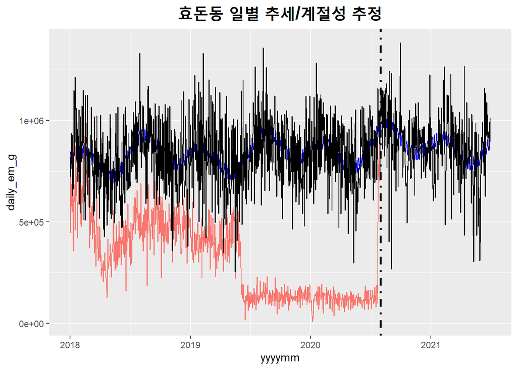

```r
hyodon_fill_na %>% ggplot() +
  geom_line(data = hyodon_fill_na1, aes(x = yyyymm, y = daily_em_g), color = 'blue') +
  geom_line(data = hyodon_na_dong[1:943, ], aes(x = base_date, y = sum_em_g, color = 'red')) +
  geom_line(aes(x = yyyymm, y = daily_em_g)) +
  geom_vline(xintercept = as.Date('2020-08-01'), linetype = 4, size = 1) +
  labs(title = "효돈동 일별 추세/계절성 추정") +
  theme(plot.title = element_text(face = "bold", size = 18, hjust = 0.5), legend.position = "none")
```

#### 영천동

```r
n = all_n - 944 + 1
t = c(944:all_n) # for regression
m1 = n/7; m2 = n/182.5; m3 = n/365
costerm1 = cos(m1*2*pi/n*t); sinterm1 = sin(m1*2*pi/n*t); costerm2 = cos(m2*2*pi/n*t); sinterm2 = sin(m2*2*pi/n*t)
costerm3 = cos(m3*2*pi/n*t); sinterm3 = sin(m3*2*pi/n*t)

yeongcheon_na_dong = daily_raw_data %>% filter(emd_nm == '영천동') %>% select(-emd_nm)
yeongcheon_spline = data.frame(daily_date_time, na_interpolation(yeongcheon_na_dong$sum_em_g, option = 'spline'))
colnames(yeongcheon_spline) = c('yyyymm', 'daily_em_g')

est_yeongcheon = lm(yeongcheon_spline$daily_em_g[944:all_n] ~ 1 + costerm1 + sinterm1 + costerm2 + sinterm2 + costerm3 + sinterm3)
sd_yeongcheon = ((est_yeongcheon$residuals^2 %>% sum) / n) %>% sqrt
est_yeongcheon_coef = est_yeongcheon$coefficients

y_time_seq = est_yeongcheon_coef[1] + #est_yeongcheon_coef[2]*time_seq +
  est_yeongcheon_coef[2]*cos(m1*2*pi/n * time_seq) + est_yeongcheon_coef[3]*sin(m1*2*pi/n * time_seq) +
  est_yeongcheon_coef[4]*cos(m2*2*pi/n * time_seq) + est_yeongcheon_coef[5]*sin(m2*2*pi/n * time_seq) +
  est_yeongcheon_coef[6]*cos(m3*2*pi/n * time_seq) + est_yeongcheon_coef[7]*sin(m3*2*pi/n * time_seq) + rnorm(all_n, 0, sd_yeongcheon)
yeongcheon_fill_na = data.frame(daily_date_time, '영천동', c(y_time_seq[1:943], yeongcheon_spline[944:all_n, 'daily_em_g']))
colnames(yeongcheon_fill_na) = c('yyyymm', 'emd_nm', 'daily_em_g')
```

### 성산읍

성산읍은 20년 7월과 21년 5월에 관측기기별로 결측치가 연속적으로 존재합니다. 그 부분도 추가적으로 이상치 대체를 진행합니다.

```r
make_na_index = daily_date_time >= as.Date('2020-06-30') & daily_date_time <= as.Date('2020-07-24')|
  (daily_date_time >= as.Date('2021-05-22') & daily_date_time <= as.Date('2021-06-08'))
n = daily_date_time %>% unlist() %>% length() - make_na_index %>% sum
t = c(366:911, 937:1237, 1256:all_n)
m1 = all_n/7; m2 = all_n/182.5; m3 = all_n/365
costerm1 = cos(m1*2*pi/all_n*t); sinterm1 = sin(m1*2*pi/all_n*t); costerm2 = cos(m2*2*pi/all_n*t); sinterm2 = sin(m2*2*pi/all_n*t)
costerm3 = cos(m3*2*pi/all_n*t); sinterm3 = sin(m3*2*pi/all_n*t)

seongsan_na_dong = daily_raw_data %>% filter(emd_nm == '성산읍') %>% select(-emd_nm)
seongsan_spline = data.frame(daily_date_time, na_interpolation(seongsan_na_dong$sum_em_g, option = 'spline'))
colnames(seongsan_spline) = c('yyyymm', 'daily_em_g')

est_seongsan = lm(seongsan_spline$daily_em_g[t] ~ 1 + t + costerm1 + sinterm1 + costerm2 + sinterm2 + costerm3 + sinterm3)
sd_seongsan = ((est_seongsan$residuals^2 %>% sum) / n) %>% sqrt
est_seongsan_coef = est_seongsan$coefficients

y_time_seq = est_seongsan_coef[1] + est_seongsan_coef[2]*time_seq +
  est_seongsan_coef[3]*cos(m1*2*pi/all_n * time_seq) + est_seongsan_coef[4]*sin(m1*2*pi/all_n * time_seq) +
  est_seongsan_coef[5]*cos(m2*2*pi/all_n * time_seq) + est_seongsan_coef[6]*sin(m2*2*pi/all_n * time_seq) +
  est_seongsan_coef[7]*cos(m3*2*pi/all_n * time_seq) + est_seongsan_coef[8]*sin(m3*2*pi/all_n * time_seq) + rnorm(all_n, 0, sd_seongsan)
seongsan_em_g = c(y_time_seq[1:365], seongsan_spline[366:911, 'daily_em_g'], y_time_seq[912:936],
                  seongsan_spline[937:1237, 'daily_em_g'], y_time_seq[1238:1255], seongsan_spline[1256:all_n, 'daily_em_g'])
seongsan_fill_na = data.frame(daily_date_time, '성산읍', seongsan_em_g)
colnames(seongsan_fill_na) = c('yyyymm', 'emd_nm', 'daily_em_g')
```

#### 표선면

```r
make_na_index = daily_date_time >= as.Date('2020-06-30') & daily_date_time <= as.Date('2020-07-24')|
  (daily_date_time >= as.Date('2021-05-22') & daily_date_time <= as.Date('2021-06-08'))
n = daily_date_time %>% unlist() %>% length() - make_na_index %>% sum
t = c(366:all_n)
m1 = all_n/7; m2 = all_n/182.5; m3 = all_n/365
costerm1 = cos(m1*2*pi/all_n*t); sinterm1 = sin(m1*2*pi/all_n*t); costerm2 = cos(m2*2*pi/all_n*t); sinterm2 = sin(m2*2*pi/all_n*t)
costerm3 = cos(m3*2*pi/all_n*t); sinterm3 = sin(m3*2*pi/all_n*t)

pyoseon_na_dong = daily_raw_data %>% filter(emd_nm == '표선면') %>% select(-emd_nm)
pyoseon_spline = data.frame(daily_date_time, na_interpolation(pyoseon_na_dong$sum_em_g, option = 'spline'))
colnames(pyoseon_spline) = c('yyyymm', 'daily_em_g')

est_pyoseon = lm(pyoseon_spline$daily_em_g[t] ~ 1 + t + costerm1 + sinterm1 + costerm2 + sinterm2 + costerm3 + sinterm3)
sd_pyoseon = ((est_pyoseon$residuals^2 %>% sum) / n) %>% sqrt
est_pyoseon_coef = est_pyoseon$coefficients

y_time_seq = est_pyoseon_coef[1] + est_pyoseon_coef[2]*time_seq +
  est_pyoseon_coef[3]*cos(m1*2*pi/all_n * time_seq) + est_pyoseon_coef[4]*sin(m1*2*pi/all_n * time_seq) +
  est_pyoseon_coef[5]*cos(m2*2*pi/all_n * time_seq) + est_pyoseon_coef[6]*sin(m2*2*pi/all_n * time_seq) +
  est_pyoseon_coef[7]*cos(m3*2*pi/all_n * time_seq) + est_pyoseon_coef[8]*sin(m3*2*pi/all_n * time_seq) + rnorm(all_n, 0, sd_pyoseon)
pyoseon_em_g = c(y_time_seq[1:365], pyoseon_spline[366:all_n, 'daily_em_g'])
pyoseon_fill_na = data.frame(daily_date_time, '표선면', pyoseon_em_g)
colnames(pyoseon_fill_na) = c('yyyymm', 'emd_nm', 'daily_em_g')
```

#### 안덕면

안덕면의 경우 2019년 7월부터의 관측치를 정상의 범주로 다루고, 다만 그 안에서 연속적으로 결측이 발생했던 19년 9~10월의 데이터에 대해서 추가적으로 이상치를 대체합니다.

```r
make_na_index = daily_date_time >= as.Date('2019-09-01') & daily_date_time <= as.Date('2019-10-16')
n = daily_date_time %>% length() - make_na_index %>% sum - 546
t = c(547:608, 655:all_n) # for regression
m1 = n/7; m2 = n/182.5; m3 = n/365
costerm1 = cos(m1*2*pi/n*t); sinterm1 = sin(m1*2*pi/n*t); costerm2 = cos(m2*2*pi/n*t); sinterm2 = sin(m2*2*pi/n*t)
costerm3 = cos(m3*2*pi/n*t); sinterm3 = sin(m3*2*pi/n*t)

ahndeok_na_dong = daily_raw_data %>% filter(emd_nm == '안덕면') %>% select(-emd_nm)
ahndeok_spline = data.frame(daily_date_time, na_interpolation(ahndeok_na_dong$sum_em_g, option = 'spline'))
colnames(ahndeok_spline) = c('yyyymm', 'daily_em_g')

est_ahndeok = lm(ahndeok_spline$daily_em_g[t] ~ 1 + t + costerm1 + sinterm1 + costerm2 + sinterm2 + costerm3 + sinterm3)
sd_ahndeok = ((est_ahndeok$residuals^2 %>% sum) / n) %>% sqrt
est_ahndeok_coef = est_ahndeok$coefficients

y_time_seq = est_ahndeok_coef[1] + est_ahndeok_coef[2]*time_seq +
  est_ahndeok_coef[3]*cos(m1*2*pi/n * time_seq) + est_ahndeok_coef[4]*sin(m1*2*pi/n * time_seq) +
  est_ahndeok_coef[5]*cos(m2*2*pi/n * time_seq) + est_ahndeok_coef[6]*sin(m2*2*pi/n * time_seq) +
  est_ahndeok_coef[7]*cos(m3*2*pi/n * time_seq) + est_ahndeok_coef[8]*sin(m3*2*pi/n * time_seq) + rnorm(all_n, 0, sd_ahndeok)
ahndeok_fill_na = data.frame(daily_date_time, '안덕면', c(y_time_seq[1:546], ahndeok_spline[547:608, 'daily_em_g'],
                                                       y_time_seq[609:654], ahndeok_spline[655:all_n, 'daily_em_g']))
colnames(ahndeok_fill_na) = c('yyyymm', 'emd_nm', 'daily_em_g')
```

안덕면의 이상치 대체에 대한 결과 시각화입니다.

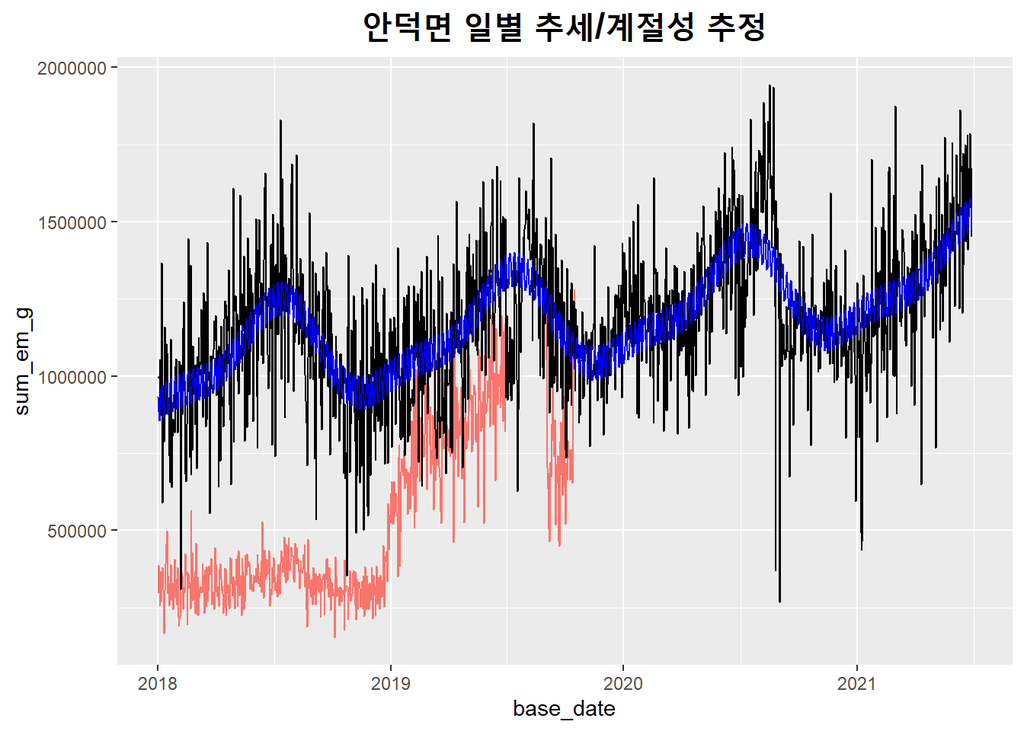

```r
y_time_seq1 = est_ahndeok_coef[1] + est_ahndeok_coef[2]*time_seq +
  est_ahndeok_coef[3]*cos(m1*2*pi/n * time_seq) + est_ahndeok_coef[4]*sin(m1*2*pi/n * time_seq) +
  est_ahndeok_coef[5]*cos(m2*2*pi/n * time_seq) + est_ahndeok_coef[6]*sin(m2*2*pi/n * time_seq) +
  est_ahndeok_coef[7]*cos(m3*2*pi/n * time_seq) + est_ahndeok_coef[8]*sin(m3*2*pi/n * time_seq)
ahndeok_fill_na1 = data.frame(daily_date_time, '안덕면', y_time_seq1)
colnames(ahndeok_fill_na1) = c('yyyymm', 'emd_nm', 'daily_em_g')

ahndeok_fill_na %>% ggplot() +
  geom_line(data = ahndeok_na_dong[1:546, ], aes(x = base_date, y = sum_em_g, color = 'red')) +
  geom_line(data = ahndeok_na_dong[609:654, ], aes(x = base_date, y = sum_em_g, color = 'red')) +
  geom_line(aes(x = yyyymm, y = daily_em_g)) +
  geom_line(data = ahndeok_fill_na1, aes(x = yyyymm, y = daily_em_g), color = 'blue') +
  labs(title = "안덕면 일별 추세/계절성 추정") +
  theme(plot.title = element_text(face = "bold", size = 18, hjust = 0.5), legend.position = "none")
```

#### 대정읍

대정읍 또한 안덕면과 유사한 패턴을 지닙니다.

```r
make_na_index = (daily_date_time >= as.Date('2019-09-01') & daily_date_time <= as.Date('2019-10-16')) |
  (daily_date_time >= as.Date('2020-06-21') & daily_date_time <= as.Date('2020-07-10'))
n = daily_date_time %>% length() - make_na_index %>% sum - 546
t = c(547:608, 655:902, 923:all_n) # for regression
m1 = n/7; m2 = n/182.5; m3 = n/365
costerm1 = cos(m1*2*pi/n*t); sinterm1 = sin(m1*2*pi/n*t); costerm2 = cos(m2*2*pi/n*t); sinterm2 = sin(m2*2*pi/n*t)
costerm3 = cos(m3*2*pi/n*t); sinterm3 = sin(m3*2*pi/n*t)

daejeong_na_dong = daily_raw_data %>% filter(emd_nm == '대정읍') %>% select(-emd_nm)
daejeong_spline = data.frame(daily_date_time, na_interpolation(daejeong_na_dong$sum_em_g, option = 'spline'))
colnames(daejeong_spline) = c('yyyymm', 'daily_em_g')

est_daejeong = lm(daejeong_spline$daily_em_g[t] ~ 1 + t + costerm1 + sinterm1 + costerm2 + sinterm2 + costerm3 + sinterm3)
sd_daejeong = ((est_daejeong$residuals^2 %>% sum) / n) %>% sqrt
est_daejeong_coef = est_daejeong$coefficients

y_time_seq = est_daejeong_coef[1] + est_daejeong_coef[2]*time_seq +
  est_daejeong_coef[3]*cos(m1*2*pi/n * time_seq) + est_daejeong_coef[4]*sin(m1*2*pi/n * time_seq) +
  est_daejeong_coef[5]*cos(m2*2*pi/n * time_seq) + est_daejeong_coef[6]*sin(m2*2*pi/n * time_seq) +
  est_daejeong_coef[7]*cos(m3*2*pi/n * time_seq) + est_daejeong_coef[8]*sin(m3*2*pi/n * time_seq) + rnorm(all_n, 0, sd_daejeong)
daejeong_fill_na = data.frame(daily_date_time, '대정읍', c(y_time_seq[1:546], daejeong_spline[547:608, 'daily_em_g'],
                                                        y_time_seq[609:654], daejeong_spline[655:902, 'daily_em_g'],
                                                        y_time_seq[903:922], daejeong_spline[923:all_n, 'daily_em_g']))
colnames(daejeong_fill_na) = c('yyyymm', 'emd_nm', 'daily_em_g')
```

이렇게 데이터들에 이상치를 대체하고, 데이터를 우선 합치도록 하겠습니다.

#### 데이터 병합

```r
outlier_dong = c('남원읍', '대륜동', '대천동', '동홍동', '서홍동', '송산동', '예래동', '정방동', '중문동', '중앙동', '천지동',
                 '효돈동', '안덕면', '대정읍', '영천동', '구좌읍', '애월읍', '조천읍', '한경면', '한림읍', '성산읍', '표선면')


outlier_dong_interpolation = bind_rows(namwon_fill_na, daeryun_fill_na, daecheon_fill_na, donghong_fill_na, seohong_fill_na,
                                       songsan_fill_na, yerae_fill_na, jeongbang_fill_na, joongmoon_fill_na, joongang_fill_na,
                                       cheonji_fill_na, hyodon_fill_na, ahndeok_fill_na, daejeong_fill_na, yeongcheon_fill_na,
                                       goojwa_fill_na, aeweol_fill_na, chocheon_fill_na, hangyeong_fill_na, hanrim_fill_na,
                                       seongsan_fill_na, pyoseon_fill_na)


na_dong = c('건입동', '노형동', '도두동', '봉개동', '삼도1동', '삼도2동', '삼양동', '아라동', '연동',
            '오라동', '외도동', '용담1동', '용담2동', '이도1동', '이도2동', '이호동', '일도1동', '일도2동', '화북동')
```

### 1.2.4 제주시 행정동 결측치 보간

위에서 전처리를 하지 않은 행정동들에는 이상치나 결측치가 인접한 행정동들간에 유사한 패턴으로 나오지 않습니다. 다만 2020년 10월 23일의 경우 대부분의 행정동에서 결측이 발생했으므로, 이를 스플라인 보간법을 통해 채워줍니다. 더불어 매우 짧은 기간 결측이 발생하는 경우도 스플라인 보간법을 통해 다룹니다.

```r
# 건입동
geonip_na_dong = daily_date_time %>% as.data.frame() %>% rename('base_date' = '.') %>%
  left_join(daily_raw_data %>% filter(emd_nm == '건입동') %>% select(-emd_nm))
geonip_spline = data.frame(daily_date_time, '건입동', na_interpolation(geonip_na_dong$sum_em_g, option = 'spline'))
colnames(geonip_spline) = c('yyyymm', 'emd_nm', 'daily_em_g')

# 노형동
nohyeong_na_dong = daily_date_time %>% as.data.frame() %>% rename('base_date' = '.') %>%
  left_join(daily_raw_data %>% filter(emd_nm == '노형동') %>% select(-emd_nm))
nohyeong_spline = data.frame(daily_date_time, '노형동', na_interpolation(nohyeong_na_dong$sum_em_g, option = 'spline'))
colnames(nohyeong_spline) = c('yyyymm', 'emd_nm', 'daily_em_g')

# 도두동
dodoo_na_dong = daily_date_time %>% as.data.frame() %>% rename('base_date' = '.') %>%
  left_join(daily_raw_data %>% filter(emd_nm == '도두동') %>% select(-emd_nm))
dodoo_spline = data.frame(daily_date_time, '도두동', na_interpolation(dodoo_na_dong$sum_em_g, option = 'spline'))
colnames(dodoo_spline) = c('yyyymm', 'emd_nm', 'daily_em_g')

# 봉개동
bonggae_na_dong = daily_date_time %>% as.data.frame() %>% rename('base_date' = '.') %>%
  left_join(daily_raw_data %>% filter(emd_nm == '봉개동') %>% select(-emd_nm))
bonggae_spline = data.frame(daily_date_time, '봉개동', na_interpolation(bonggae_na_dong$sum_em_g, option = 'spline'))
colnames(bonggae_spline) = c('yyyymm', 'emd_nm', 'daily_em_g')

# 삼도1동
samdoone_na_dong = daily_date_time %>% as.data.frame() %>% rename('base_date' = '.') %>%
  left_join(daily_raw_data %>% filter(emd_nm == '삼도1동') %>% select(-emd_nm))
samdoone_spline = data.frame(daily_date_time, '삼도1동', na_interpolation(samdoone_na_dong$sum_em_g, option = 'spline'))
colnames(samdoone_spline) = c('yyyymm', 'emd_nm', 'daily_em_g')

# 삼도2동
samdotwo_na_dong = daily_date_time %>% as.data.frame() %>% rename('base_date' = '.') %>%
  left_join(daily_raw_data %>% filter(emd_nm == '삼도2동') %>% select(-emd_nm))
samdotwo_spline = data.frame(daily_date_time, '삼도2동', na_interpolation(samdotwo_na_dong$sum_em_g, option = 'spline'))
colnames(samdotwo_spline) = c('yyyymm', 'emd_nm', 'daily_em_g')

# 삼양동
samyang_na_dong = daily_date_time %>% as.data.frame() %>% rename('base_date' = '.') %>%
  left_join(daily_raw_data %>% filter(emd_nm == '삼양동') %>% select(-emd_nm))
samyang_spline = data.frame(daily_date_time, '삼양동', na_interpolation(samyang_na_dong$sum_em_g, option = 'spline'))
colnames(samyang_spline) = c('yyyymm', 'emd_nm', 'daily_em_g')

# 아라동
ahrah_na_dong = daily_date_time %>% as.data.frame() %>% rename('base_date' = '.') %>%
  left_join(daily_raw_data %>% filter(emd_nm == '아라동') %>% select(-emd_nm))
ahrah_spline = data.frame(daily_date_time, '아라동', na_interpolation(ahrah_na_dong$sum_em_g, option = 'spline'))
colnames(ahrah_spline) = c('yyyymm', 'emd_nm', 'daily_em_g')

# 연동
yeon_na_dong = daily_date_time %>% as.data.frame() %>% rename('base_date' = '.') %>%
  left_join(daily_raw_data %>% filter(emd_nm == '연동') %>% select(-emd_nm))
yeon_spline = data.frame(daily_date_time, '연동', na_interpolation(yeon_na_dong$sum_em_g, option = 'spline'))
colnames(yeon_spline) = c('yyyymm', 'emd_nm', 'daily_em_g')

# 오라동
ohrah_na_dong = daily_date_time %>% as.data.frame() %>% rename('base_date' = '.') %>%
  left_join(daily_raw_data %>% filter(emd_nm == '오라동') %>% select(-emd_nm))
ohrah_spline = data.frame(daily_date_time, '오라동', na_interpolation(ohrah_na_dong$sum_em_g, option = 'spline'))
colnames(ohrah_spline) = c('yyyymm', 'emd_nm', 'daily_em_g')

# 외도동
oedo_na_dong = daily_date_time %>% as.data.frame() %>% rename('base_date' = '.') %>%
  left_join(daily_raw_data %>% filter(emd_nm == '외도동') %>% select(-emd_nm))
oedo_spline = data.frame(daily_date_time, '외도동', na_interpolation(oedo_na_dong$sum_em_g, option = 'spline'))
colnames(oedo_spline) = c('yyyymm', 'emd_nm', 'daily_em_g')

# 용담1동
yongdamone_na_dong = daily_date_time %>% as.data.frame() %>% rename('base_date' = '.') %>%
  left_join(daily_raw_data %>% filter(emd_nm == '용담1동') %>% select(-emd_nm))
yongdamone_spline = data.frame(daily_date_time, '용담1동', na_interpolation(yongdamone_na_dong$sum_em_g, option = 'spline'))
colnames(yongdamone_spline) = c('yyyymm', 'emd_nm', 'daily_em_g')

# 용담2동
yongdamtwo_na_dong = daily_date_time %>% as.data.frame() %>% rename('base_date' = '.') %>%
  left_join(daily_raw_data %>% filter(emd_nm == '용담2동') %>% select(-emd_nm))
yongdamtwo_spline = data.frame(daily_date_time, '용담2동', na_interpolation(yongdamtwo_na_dong$sum_em_g, option = 'spline'))
colnames(yongdamtwo_spline) = c('yyyymm', 'emd_nm', 'daily_em_g')

# 이도2동
idotwo_na_dong = daily_date_time %>% as.data.frame() %>% rename('base_date' = '.') %>%
  left_join(daily_raw_data %>% filter(emd_nm == '이도2동') %>% select(-emd_nm))
idotwo_spline = data.frame(daily_date_time, '이도2동', na_interpolation(idotwo_na_dong$sum_em_g, option = 'spline'))
colnames(idotwo_spline) = c('yyyymm', 'emd_nm', 'daily_em_g')

# 이호동
iho_na_dong = daily_date_time %>% as.data.frame() %>% rename('base_date' = '.') %>%
  left_join(daily_raw_data %>% filter(emd_nm == '이호동') %>% select(-emd_nm))
iho_spline = data.frame(daily_date_time, '이호동', na_interpolation(iho_na_dong$sum_em_g, option = 'spline'))
colnames(iho_spline) = c('yyyymm', 'emd_nm', 'daily_em_g')

# 일도2동
ildotwo_na_dong = daily_date_time %>% as.data.frame() %>% rename('base_date' = '.') %>%
  left_join(daily_raw_data %>% filter(emd_nm == '일도2동') %>% select(-emd_nm))
ildotwo_spline = data.frame(daily_date_time, '일도2동', na_interpolation(ildotwo_na_dong$sum_em_g, option = 'spline'))
colnames(ildotwo_spline) = c('yyyymm', 'emd_nm', 'daily_em_g')

# 화북동
hwabook_na_dong = daily_date_time %>% as.data.frame() %>% rename('base_date' = '.') %>%
  left_join(daily_raw_data %>% filter(emd_nm == '화북동') %>% select(-emd_nm))
hwabook_spline = data.frame(daily_date_time, '화북동', na_interpolation(hwabook_na_dong$sum_em_g, option = 'spline'))
colnames(hwabook_spline) = c('yyyymm', 'emd_nm', 'daily_em_g')
```

#### ’알수없음’의 경우

’알수없음’의 경우, 2020년 7월 이후 관측되는 기기가 단 한 개입니다. 따라서 해당 관측기기의 첫 관측부터 다루도록 합니다.

```r
unknown = raw_data %>% filter(emd_nm == '알수없음' & em_area_cd == 'W6Y71C') %>% select(base_date, em_g)
unknown_na_dong = daily_date_time %>% as.data.frame() %>% rename('base_date' = '.') %>% filter(base_date >= as.Date('2020-07-14')) %>%
  left_join(unknown)
unknown_spline = data.frame(unknown_na_dong$base_date, '알수없음', na_interpolation(unknown_na_dong$em_g, option = 'spline'))
colnames(unknown_spline) = c('yyyymm', 'emd_nm', 'daily_em_g')
```

#### 이도1동과 일도1동

이도1동과 일도1동의 경우, 2021년 6월 10일 이후 연속적인 결측이 발생했습니다. 그에 따라 전체적인 추세로 보았을때 급감하는 형태가 드러납니다. 이도1동과 일도1동의 해당 이상치의 경우, 전체 기간의 데이터를 활용하기보다, 근접한 데이터만 활용해서 이상치를 처리하도록 하겠습니다.

```r
n = 1262 - 1200
t = 1200:1262 # for regression
m1 = n/7; m2 = n/182.5; m3 = n/365
costerm1 = cos(m1*2*pi/n*t); sinterm1 = sin(m1*2*pi/n*t)

idoone_na_dong = daily_date_time %>% as.data.frame() %>% rename('base_date' = '.') %>%
  left_join(daily_raw_data %>% filter(emd_nm == '이도1동') %>% select(-emd_nm))
idoone_spline = data.frame(daily_date_time, '이도1동', na_interpolation(idoone_na_dong$sum_em_g, option = 'spline'))
colnames(idoone_spline) = c('yyyymm', 'emd_nm', 'daily_em_g')

est_idoone = lm(idoone_spline$daily_em_g[1200:1262] ~ 1 + t + costerm1 + sinterm1)
sd_idoone = ((est_idoone$residuals^2 %>% sum) / n) %>% sqrt
est_idoone_coef = est_idoone$coefficients

y_time_seq = est_idoone_coef[1] + est_idoone_coef[2]*time_seq +
  est_idoone_coef[2]*cos(m1*2*pi/n * time_seq) + est_idoone_coef[3]*sin(m1*2*pi/n * time_seq) + rnorm(all_n, 0, sd_idoone)
idoone_fill_na = data.frame(daily_date_time, '이도1동', c(idoone_spline[1:1262, 'daily_em_g'], y_time_seq[1263:all_n]))
colnames(idoone_fill_na) = c('yyyymm', 'emd_nm', 'daily_em_g')
```

이도1동의 보간결과를 시각화하겠습니다.

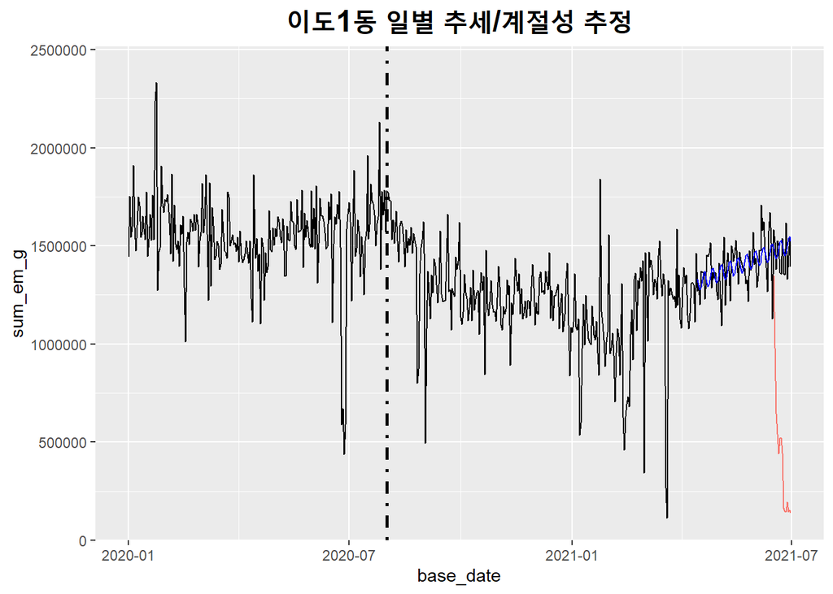

```r
y_time_seq1 = est_idoone_coef[1] + est_idoone_coef[2]*time_seq +
  est_idoone_coef[2]*cos(m1*2*pi/n * time_seq) + est_idoone_coef[3]*sin(m1*2*pi/n * time_seq)
idoone_fill_na1 = data.frame(daily_date_time, '이도1동', y_time_seq1)
colnames(idoone_fill_na1) = c('yyyymm', 'emd_nm', 'daily_em_g')

idoone_fill_na %>% ggplot() +
  geom_line(data = idoone_na_dong[1263:1277, ], aes(x = base_date, y = sum_em_g, color = 'red')) +
  geom_line(aes(x = yyyymm, y = daily_em_g)) +
  geom_line(data = idoone_fill_na1[1200:1277, ], aes(x = yyyymm, y = daily_em_g), color = 'blue') +
  geom_vline(xintercept = as.Date('2020-08-01'), linetype = 4, size = 1) +
  xlim(as.Date('2020-01-01'), as.Date('2021-06-30')) +
  labs(title = "이도1동 일별 추세/계절성 추정") +
  theme(plot.title = element_text(face = "bold", size = 18, hjust = 0.5), legend.position = "none")
```

다음은 일도1동을 이도1동과 동일한 방식으로 보간한 과정입니다.

```r
n = 1256 - 1200
t = 1200:1256 # for regression
m1 = n/7; m2 = n/182.5; m3 = n/365
costerm1 = cos(m1*2*pi/n*t); sinterm1 = sin(m1*2*pi/n*t)

ildoone_na_dong = daily_date_time %>% as.data.frame() %>% rename('base_date' = '.') %>%
  left_join(daily_raw_data %>% filter(emd_nm == '일도1동') %>% select(-emd_nm))
ildoone_na_dong[ildoone_na_dong$sum_em_g %>% is.na %>% which, ]
```

```
##       base_date sum_em_g
## 1175 2021-03-20       NA
## 1266 2021-06-19       NA
## 1267 2021-06-20       NA
## 1268 2021-06-21       NA
## 1269 2021-06-22       NA
## 1270 2021-06-23       NA
## 1271 2021-06-24       NA
## 1272 2021-06-25       NA
## 1273 2021-06-26       NA
## 1274 2021-06-27       NA
## 1275 2021-06-28       NA
## 1276 2021-06-29       NA
## 1277 2021-06-30       NA
```

```r
ildoone_spline = data.frame(daily_date_time, '일도1동', na_interpolation(ildoone_na_dong$sum_em_g, option = 'spline'))
colnames(ildoone_spline) = c('yyyymm', 'emd_nm', 'daily_em_g')

est_ildoone = lm(ildoone_spline$daily_em_g[1200:1256] ~ 1 + t + costerm1 + sinterm1)
sd_ildoone = ((est_ildoone$residuals^2 %>% sum) / n) %>% sqrt
est_ildoone_coef = est_ildoone$coefficients

y_time_seq = est_ildoone_coef[1] + est_ildoone_coef[2]*time_seq +
  est_ildoone_coef[2]*cos(m1*2*pi/n * time_seq) + est_ildoone_coef[3]*sin(m1*2*pi/n * time_seq) + rnorm(all_n, 0, sd_idoone)
ildoone_fill_na = data.frame(daily_date_time, '일도1동', c(ildoone_spline[1:1256, 'daily_em_g'], y_time_seq[1257:all_n]))
colnames(ildoone_fill_na) = c('yyyymm', 'emd_nm', 'daily_em_g')
```

### 1.2.5 보간 데이터 완성

결과들을 모두 종합한 데이터를 만듭니다.

```r
daily_raw_data =
  outlier_dong_interpolation %>%
  bind_rows(geonip_spline, nohyeong_spline, dodoo_spline, bonggae_spline, samdoone_spline,
            samdotwo_spline, samyang_spline, ahrah_spline, yeon_spline,
            ohrah_spline, oedo_spline, yongdamone_spline, yongdamtwo_spline, idoone_fill_na,
            idotwo_spline, iho_spline, ildoone_fill_na, ildotwo_spline, hwabook_spline, unknown_spline) %>%
  arrange(yyyymm, emd_nm) %>%
  mutate(daily_em_g = round(daily_em_g, -1))
```

### 1.2.6 보간 데이터 결과 확인

#### 일별 보간 결과 확인

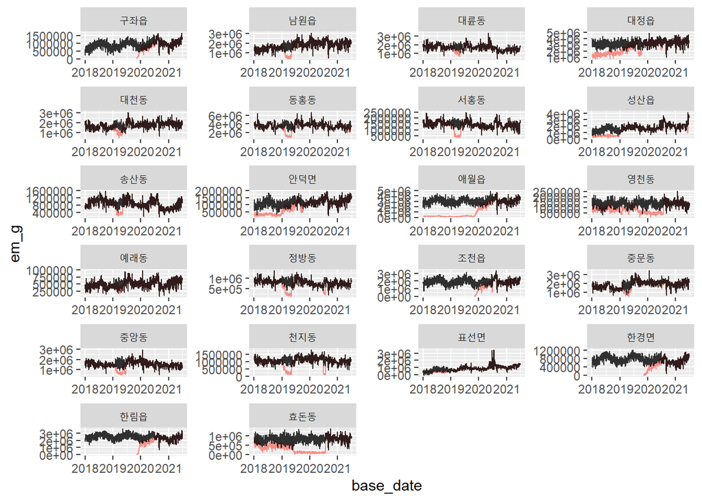

```r
daily_unimputed_data = raw_data %>% group_by(base_date, emd_nm) %>% summarise(em_g = sum(em_g)) %>%
  ungroup() %>% filter(emd_nm != '알수없음')
daily_imputed_data = daily_raw_data %>% select(yyyymm, emd_nm, daily_em_g) %>% rename(base_date = 'yyyymm')

daily_imputed_data %>% left_join(daily_unimputed_data) %>% filter(emd_nm %in% outlier_dong) %>%
  ggplot() +
  geom_line(aes(x = base_date, y = em_g, color = 'red'), alpha = 0.8) +
  geom_line(aes(x = base_date, y = daily_em_g), alpha = 0.8) +
  facet_wrap(~emd_nm, nrow = 7, scales = 'free') +
  theme(legend.position = 'none')
```

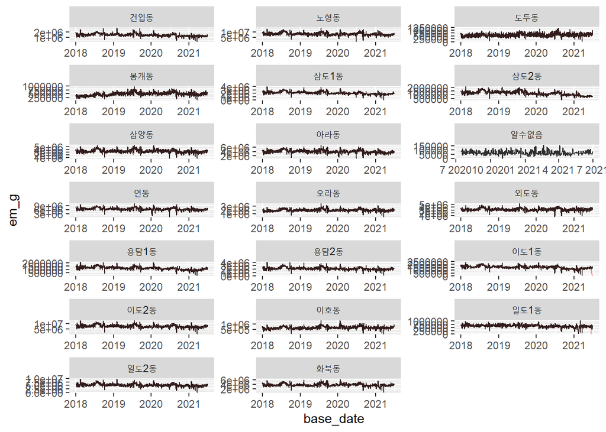

```r
daily_imputed_data %>% left_join(daily_unimputed_data) %>% filter(emd_nm %notin% outlier_dong) %>%
  ggplot() +
  geom_line(aes(x = base_date, y = em_g, color = 'red'), alpha = 0.8) +
  geom_line(aes(x = base_date, y = daily_em_g), alpha = 0.8) +
  facet_wrap(~emd_nm, nrow = 7, scales = 'free') +
  theme(legend.position = 'none')
```

#### 월별 보간 결과 확인

```r
monthly_unimputed_data =
  daily_unimputed_data %>% mutate(base_year = year(base_date), base_month = month(base_date)) %>%
  group_by(base_year, base_month, emd_nm) %>% summarise(em_g = sum(em_g)) %>% ungroup %>%
  mutate(base_date = paste0(base_year,"-", base_month) %>% ym())
monthly_imputed_data =
  daily_imputed_data %>% mutate(base_year = year(base_date), base_month = month(base_date)) %>%
  group_by(base_year, base_month, emd_nm) %>% summarise(monthly_em_g = sum(daily_em_g)) %>% ungroup %>%
  mutate(base_date = paste0(base_year,"-", base_month) %>% ym())
```

월별 시각화 결과입니다.

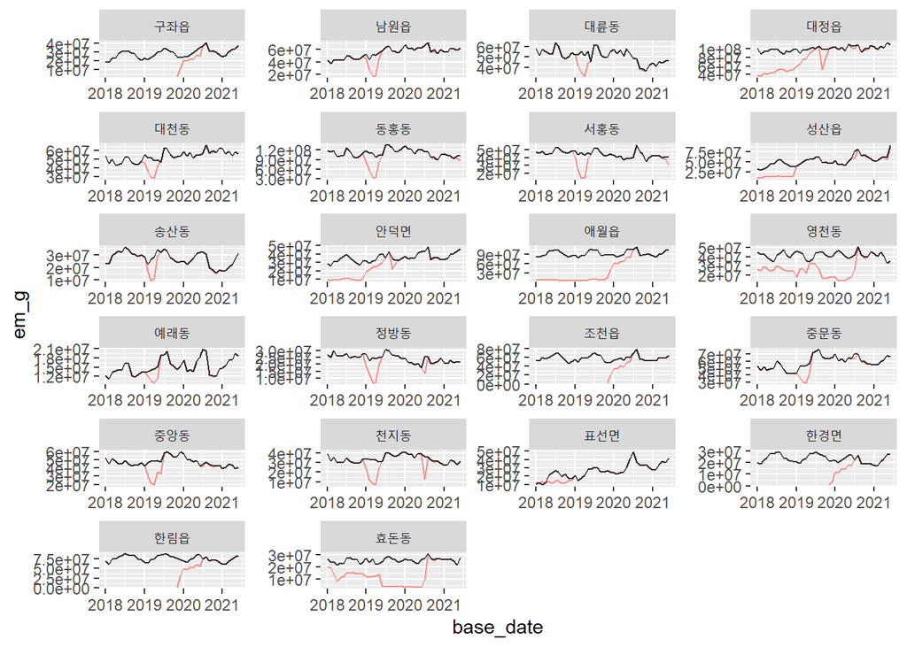

```r
monthly_imputed_data %>% left_join(monthly_unimputed_data) %>% filter(emd_nm %in% outlier_dong) %>%
  ggplot() +
  geom_line(aes(x = base_date, y = em_g, color = 'red'), alpha = 0.8) +
  geom_line(aes(x = base_date, y = monthly_em_g), alpha = 0.8) +
  facet_wrap(~emd_nm, nrow = 7, scales = 'free') +
  theme(legend.position = 'none')
```

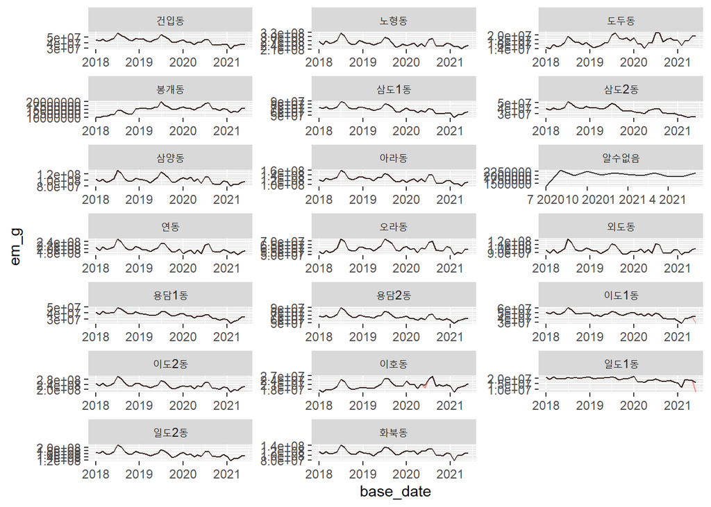

```r
monthly_imputed_data %>% left_join(monthly_unimputed_data) %>% filter(emd_nm %notin% outlier_dong) %>%
  ggplot() +
  geom_line(aes(x = base_date, y = em_g, color = 'red'), alpha = 0.8) +
  geom_line(aes(x = base_date, y = monthly_em_g), alpha = 0.8) +
  facet_wrap(~emd_nm, nrow = 7, scales = 'free') +
  theme(legend.position = 'none')
```

# 2. 데이터 병합

배출량 데이터에 추가적으로 주어진 데이터와 외부데이터를 결합하는 과정입니다.

## 2.1 기본데이터 병합

### 2.1.1 유동인구 데이터

주어진 유동인구 데이터를 불러옵니다.

1. 제주 거주인들의 일별/행정동별 거주세대 비율 변수를 생성합니다.
2. 제주도가 아닌 외부거주인들의 일별/행정동별 방문세대 비율변수를 생성합니다.
3. 마지막으로 일별/행정동별 총 거주/근무/방문인구 수를 계산합니다.

```r
dat2 = data.table::fread('data/02-1_내국인유동인구_KOREAN.csv')

processed2_resdprop =
  dat2 %>%
  mutate(xyz = ifelse(age <= 10, 'baby', ifelse(age <= 30, 'YZ', ifelse(age <= 50, 'X', 'old')))) %>%
  filter(resd == '제주') %>%
  group_by(emd_nm, base_date, xyz) %>%
  summarise(total_resd = sum(resd_pop_cnt)) %>%
  ungroup() %>%
  spread(xyz, total_resd) %>%
  mutate(total = baby + old + X + YZ) %>%
  mutate(baby_resd_prop = baby/total, YZ_resd_prop = YZ/total, X_resd_prop = X/total, old_resd_prop = old/total) %>%
  select(-baby, -old, -X, -YZ, -total)

processed2_visitprop =
  dat2 %>%
  mutate(xyz = ifelse(age <= 10, 'baby', ifelse(age <= 30, 'YZ', ifelse(age <= 50, 'X', 'old')))) %>%
  filter(resd == '그외') %>%
  group_by(emd_nm, base_date, xyz) %>%
  summarise(total_visit = sum(visit_pop_cnt)) %>%
  ungroup() %>%
  spread(xyz, total_visit) %>%
  mutate(total = baby + old + X + YZ) %>%
  mutate(baby_visit_prop = baby/total, YZ_visit_prop = YZ/total, X_visit_prop = X/total, old_visit_prop = old/total) %>%
  select(-baby, -old, -X, -YZ, -total)

processed2 = dat2 %>%
  group_by(emd_nm, base_date) %>%
  summarise(total_resd = sum(resd_pop_cnt),
            total_work = sum(work_pop_cnt),
            total_visit = sum(visit_pop_cnt)) %>%
  ungroup()

rm(dat2)
```

### 2.1.2 장기체류 외국인 유동인구 데이터

장기체류 외국인 유동인구 데이터에서는 일별/행정동별 총 외국인 거주/방문/근무인구 수를 구합니다.

```r
dat3 =  fread('data/02-2_장기체류 외국인 유동인구_LONG_TERM_FRGN.csv')

processed3 = dat3 %>%
  group_by(emd_nm, base_date) %>%
  summarise(foreign_resd = sum(resd_pop_cnt),
            foreign_visit = sum(visit_pop_cnt),
            foreign_work = sum(work_pop_cnt)) %>%
  ungroup()

rm(dat3)
```

### 2.1.3 음식관련 카드소비 데이터

해당 데이터에서는 다음의 변수들을 가져온다.

1. 일별/행정동별 총 카드소비횟수/금액
2. 일별/행정동별 **배달**에 사용된 카드소비횟수/금액
3. 일별/행정동별 **식료품 구매**에 사용된 카드소비횟수/금액
4. 일별/행정동별 **외식**에 사용된 카드소비횟수/금액

```r
dat6 = data.table::fread('data/04_음식관련 카드소비_CARD_SPENDING.csv')

processed6 = dat6 %>% group_by(base_date, emd_nm) %>%
  summarise(total_use_cnt = sum(use_cnt),
            total_use_amt = sum(use_amt))%>%
  ungroup()

dat6_delivery = dat6 %>% filter(mct_cat_nm == '배달')
processed6_del = dat6_delivery %>% group_by(base_date, emd_nm) %>%
  summarise(total_delivery_cnt = sum(use_cnt),
            total_delivery_amt = sum(use_amt)) %>%
  ungroup()

dat6_market = dat6 %>% filter(mct_cat_nm %in% c('농축수산물', '마트/슈퍼마켓', '식품'))
processed6_market = dat6_market %>% group_by(base_date, emd_nm) %>%
  summarise(total_market_cnt = sum(use_cnt),
            total_market_amt = sum(use_amt)) %>%
  ungroup()

dat6_eatout = dat6 %>% filter(mct_cat_nm %in% c('한식', '패스트푸드', '양식', '부페', '아시아음식'))
processed6_eatout = dat6_eatout %>% group_by(base_date, emd_nm) %>%
  summarise(total_eatout_cnt = sum(use_cnt),
            total_eatout_amt = sum(use_amt)) %>%
  ungroup()

rm(dat6)
rm(dat6_delivery)
rm(dat6_market)
rm(dat6_eatout)
```

### 2.2 외부데이터

외부데이터로는 행정동의 위경도/주택형태/마트, 코로나, 날씨 데이터를 사용했습니다.

### 2.2.1 위경도 데이터

위경도는 행정동별 경계지도 파일에서 구합니다. 경계지도를 그리는 폴리곤들의 위경도 좌표들의 평균을 구해서, 해당 행정동의 좌표로 이용합니다.

```r
dong_boundary = fread('data/dong_boundary.csv')

dong_center_longlat =
  dong_boundary %>%
  group_by(읍면동명칭) %>%
  summarize(center_long = mean(long),
            center_lat = mean(lat)) %>%
  ungroup()
```

이후 데이터를 합치고, 배달과 관련한 데이터중에 결측치를 0으로 대체합니다.

```r
final_data =
  daily_raw_data %>%
  mutate(base_month = month(yyyymm) ,
         base_year = year(yyyymm)) %>%
  left_join(processed2, by = c("emd_nm", 'yyyymm' = "base_date")) %>%
  left_join(processed2_resdprop, by = c("emd_nm", 'yyyymm' = "base_date")) %>%
  left_join(processed2_visitprop, by = c("emd_nm", 'yyyymm' = "base_date")) %>%
  left_join(processed3, by = c("emd_nm", 'yyyymm' = "base_date")) %>%
  left_join(processed6, by = c("emd_nm", 'yyyymm' = "base_date")) %>%
  left_join(processed6_del, by = c("emd_nm", 'yyyymm' = "base_date")) %>%
  left_join(processed6_market, by = c("emd_nm", 'yyyymm' = "base_date")) %>%
  left_join(processed6_eatout, by = c("emd_nm", 'yyyymm' = "base_date")) %>%
  left_join(dong_center_longlat, by = c('emd_nm' = '읍면동명칭'))

# 배달 결측치 0으로 대체
final_data$total_delivery_amt[is.na(final_data$total_delivery_amt)] = 0
final_data$total_delivery_amt[is.na(final_data$total_work)] = NA
final_data$total_delivery_cnt[is.na(final_data$total_delivery_cnt)] = 0
final_data$total_delivery_cnt[is.na(final_data$total_work)] = NA
colSums(is.na(final_data)) # 알수없음 제외 NA는 존재하지 않음
```

```
##             yyyymm             emd_nm         daily_em_g         base_month
##                  0                  0                  0                  0
##          base_year         total_resd         total_work        total_visit
##                  0                352                352                352
##     baby_resd_prop       YZ_resd_prop        X_resd_prop      old_resd_prop
##                352                352                352                352
##    baby_visit_prop      YZ_visit_prop       X_visit_prop     old_visit_prop
##                352                352                352                352
##       foreign_resd      foreign_visit       foreign_work      total_use_cnt
##                352                352                352                  0
##      total_use_amt total_delivery_cnt total_delivery_amt   total_market_cnt
##                  0                352                352                  0
##   total_market_amt   total_eatout_cnt   total_eatout_amt        center_long
##                  0                  0                  0                352
##         center_lat
##                352
```

### 2.2.2 주택 형태 데이터

행정동별 주택특성 정보를 가져온다. 행정동별 단독주택, 아파트, 연립주택, 다세대주택의 수를 계산한다.

```r
house = fread('data/주택의_종류별_주택읍면동.csv')

house = house %>% filter(연 == 2020 & `행정구역별(읍면동)` %notin% c('제주시', '서귀포시', '우도면', '추자면')) %>%
  rename(emd_nm = '행정구역별(읍면동)') %>% select(-연) %>%
  rename(single_house = '단독주택', apartment = '아파트', townhouse = '연립주택', multifamily = '다세대주택') %>%
  select(-비거주용건물내주택)

final_data = final_data %>% left_join(house, by = 'emd_nm')
```

### 2.2.3 코로나 데이터

코로나 데이터를 통해

1. 전국 코로나 일별 확진자
2. 제주 코로나 일별 확진자
3. 코로나 전후 변수

이 세가지 변수를 추가합니다.

```r
covid = fread('data/covid.csv')

covid = daily_date_time %>% as.data.frame() %>% left_join(covid, by = c('.' = 'stdDay')) %>% rename(yyyymm = '.')
# 중복 데이터 발견 후 처리
covid %>% group_by(yyyymm) %>% summarize(n_n = n()) %>% arrange(desc(n_n))
```

```
## # A tibble: 1,277 x 2
##    yyyymm       n_n
##    <date>     <int>
##  1 2020-04-11     2
##  2 2020-09-23     2
##  3 2020-12-08     2
##  4 2021-04-29     2
##  5 2018-01-01     1
##  6 2018-01-02     1
##  7 2018-01-03     1
##  8 2018-01-04     1
##  9 2018-01-05     1
## 10 2018-01-06     1
## # ... with 1,267 more rows
```

```r
covid[covid$yyyymm == as.Date('2020-04-11') & covid$jeju_covid == 0, ]
```

```
##         yyyymm jeju_covid all_covid
## 833 2020-04-11          0        30
```

```r
covid[covid$yyyymm == as.Date('2020-09-23') & covid$jeju_covid == 0, ]
```

```
##         yyyymm jeju_covid all_covid
## 999 2020-09-23          0       110
```

```r
covid[covid$yyyymm == as.Date('2020-12-08') & covid$all_covid < 0, ]
```

```
##          yyyymm jeju_covid all_covid
## 1076 2020-12-08          2      -686
```

```r
covid[covid$yyyymm == as.Date('2021-04-29') & covid$jeju_covid == 0, ]
```

```
##          yyyymm jeju_covid all_covid
## 1219 2021-04-29          0       678
```

```r
duplicated_idx = c(833, 999, 1076, 1219)
covid = covid[-duplicated_idx, ]


# 관측기간인데 결측인곳 처리
zero_day = c('2020-02-20', '2020-02-21', '2020-02-22', '2020-02-23', '2020-02-24', '2020-02-25',
             '2020-02-26', '2020-02-27', '2020-02-28', '2020-03-01', '2020-03-02',
             "2020-06-05", "2021-01-30", "2021-01-31", "2021-04-25", "2021-04-26")
covid[covid$yyyymm %in% as.Date(zero_day), 3] = c(73, 100, 229, 169, 231, 144, 284, 505, 571, 586, 599,
                                                  51, 355, 303, 500, 511)

# 제주도의 정보는 스플라인으로 처리
covid[is.na(covid)] = 0
zero_day2 = c("2020-06-05", "2021-01-30", "2021-01-31", "2021-04-25", "2021-04-26")
covid[covid$yyyymm %in% as.Date(zero_day2), 2] = NA
covid$jeju_covid = covid$jeju_covid %>% na_interpolation(option = 'spline') %>% as.integer

covid = covid %>% mutate(after_covid = ifelse(yyyymm >= as.Date('2020-02-15'), 1, 0))

final_data = final_data %>% left_join(covid, by = 'yyyymm')
```

### 2.2.4 날씨 데이터

날씨데이터를 불러오고, 이를 합칩니다.

```r
rain2018 = fread('data/weather/OBS_AWS_DD_20210815004909.csv')
rain2019 = fread('data/weather/OBS_AWS_DD_20210815004800.csv')
rain2020 = fread('data/weather/OBS_AWS_DD_20210815004708.csv')
rain2021 = fread('data/weather/OBS_AWS_DD_20210815004446.csv')

rain2018_1 = fread('data/weather/OBS_ASOS_DD_20210815015524.csv')
rain2019_1 = fread('data/weather/OBS_ASOS_DD_20210815015447.csv')
rain2020_1 = fread('data/weather/OBS_ASOS_DD_20210815015400.csv')
rain2021_1 = fread('data/weather/OBS_ASOS_DD_20210815015244.csv')

AWS = rbind(rain2018, rain2019, rain2020, rain2021)
ASOS = rbind(rain2018_1, rain2019_1, rain2020_1, rain2021_1)
```

이후 다소 복잡한 전처리를 통해 위치정보를 대조해줍니다.

```r
# ASOS 처리
final_data$new_nm = final_data$emd_nm
final_data$new_nm = ifelse(final_data$new_nm %in% c('일도2동', '일도1동', '이도1동', '이도2동', '삼도1동', '삼도2동', '용담1동',
                                                    '용담2동', '건입동', '화북동', '삼양동', '이호동', '도두동'), '제주', final_data$new_nm)
final_data$new_nm = ifelse(final_data$new_nm %in% c('송산동', '정방동', '중앙동', '천지동', '효돈동',
                                                    '영천동', '동홍동', '서홍동'), '서귀포', final_data$new_nm)
final_data$new_nm<- ifelse(final_data$new_nm == '성산읍', '성산', final_data$new_nm)
final_data$new_nm<- ifelse(final_data$new_nm == '한경면', '고산', final_data$new_nm)

names(ASOS) <- c('code', 'new_nm',"yyyymm", 'rain')
ASOS <- ASOS %>% select(-code)

# AWS 처리
final_data$new_nm<- ifelse(final_data$new_nm == '연동' | final_data$new_nm == '노형동', '어리목', final_data$new_nm)

names(AWS) <- c('code', 'emd_nm',"yyyymm", 'rain')

AWS$new_nm <- AWS$emd_nm

AWS$new_nm<- ifelse (AWS$new_nm == '한림' | AWS$new_nm == '금악', '한림읍', AWS$new_nm)
AWS$new_nm<- ifelse (AWS$new_nm == '유수암' | AWS$new_nm == '사제비' | AWS$new_nm == '윗세오름', '애월읍', AWS$new_nm)
AWS$new_nm<- ifelse (AWS$new_nm == '구좌' | AWS$new_nm == '월정' | AWS$new_nm == '송당', '구좌읍', AWS$new_nm)
AWS$new_nm<- ifelse (AWS$new_nm == '대흘' | AWS$new_nm == '선흘' | AWS$new_nm == '성판악', '조천읍', AWS$new_nm)
AWS$new_nm<- ifelse (AWS$new_nm == '한라생태숲', '봉개동', AWS$new_nm)
AWS$new_nm<- ifelse (AWS$new_nm == '산천단' | AWS$new_nm == '오등', '아라동', AWS$new_nm)
AWS$new_nm<- ifelse (AWS$new_nm == '삼각봉', '오라동', AWS$new_nm)
AWS$new_nm<- ifelse (AWS$new_nm == '외도', '외도동', AWS$new_nm)
AWS$new_nm<- ifelse (AWS$new_nm == '대정', '대정읍', AWS$new_nm)
AWS$new_nm<- ifelse (AWS$new_nm == '제주남원' | AWS$new_nm == '진달래밭' | AWS$new_nm == '대풍센터', '남원읍', AWS$new_nm)
AWS$new_nm<- ifelse (AWS$new_nm == '서광', '안덕면', AWS$new_nm)
AWS$new_nm<- ifelse (AWS$new_nm == '표선' | AWS$new_nm == '제주가시리', '표선면', AWS$new_nm)
AWS$new_nm<- ifelse (AWS$new_nm == '기상(과)', '대륜동', AWS$new_nm)
AWS$new_nm<- ifelse (AWS$new_nm == '강정', '대천동', AWS$new_nm)
AWS$new_nm<- ifelse (AWS$new_nm == '영실', '중문동', AWS$new_nm)
AWS$new_nm<- ifelse (AWS$new_nm == '중문', '예래동', AWS$new_nm)

AWS <- AWS %>% select(-code, -emd_nm)

AWS <- AWS %>% group_by(yyyymm,new_nm) %>% summarise(rain = mean(rain)) %>% ungroup
AWS <- AWS[,c(2,1,3)]
rain_final <- rbind(ASOS,AWS)

final_data = final_data %>% left_join(rain_final, by = c("yyyymm", 'new_nm')) %>% select(-new_nm)

colSums(is.na(final_data)) # 결측치 확인
```

```
##             yyyymm             emd_nm         daily_em_g         base_month
##                  0                  0                  0                  0
##          base_year         total_resd         total_work        total_visit
##                  0                352                352                352
##     baby_resd_prop       YZ_resd_prop        X_resd_prop      old_resd_prop
##                352                352                352                352
##    baby_visit_prop      YZ_visit_prop       X_visit_prop     old_visit_prop
##                352                352                352                352
##       foreign_resd      foreign_visit       foreign_work      total_use_cnt
##                352                352                352                  0
##      total_use_amt total_delivery_cnt total_delivery_amt   total_market_cnt
##                  0                352                352                  0
##   total_market_amt   total_eatout_cnt   total_eatout_amt        center_long
##                  0                  0                  0                352
##         center_lat       single_house          apartment          townhouse
##                352                352                352                352
##        multifamily         jeju_covid          all_covid        after_covid
##                352                  0                  0                  0
##               rain
##              16924
```

```r
final_data$rain[is.na(final_data$rain)] <- 0  # NA 0으로 채움(관측이 안된날짜)
colSums(is.na(final_data)) # 결측치 확인
```

```
##             yyyymm             emd_nm         daily_em_g         base_month
##                  0                  0                  0                  0
##          base_year         total_resd         total_work        total_visit
##                  0                352                352                352
##     baby_resd_prop       YZ_resd_prop        X_resd_prop      old_resd_prop
##                352                352                352                352
##    baby_visit_prop      YZ_visit_prop       X_visit_prop     old_visit_prop
##                352                352                352                352
##       foreign_resd      foreign_visit       foreign_work      total_use_cnt
##                352                352                352                  0
##      total_use_amt total_delivery_cnt total_delivery_amt   total_market_cnt
##                  0                352                352                  0
##   total_market_amt   total_eatout_cnt   total_eatout_amt        center_long
##                  0                  0                  0                352
##         center_lat       single_house          apartment          townhouse
##                352                352                352                352
##        multifamily         jeju_covid          all_covid        after_covid
##                352                  0                  0                  0
##               rain
##                  0
```

### 2.2.5 행정동별 대형마트/대형슈퍼 개수

행정동별 대형마트, 대형슈퍼 등의 식료품점의 개수를 크롤링하고, 이들의 가중평균을 주성분분석(PCA)를 통해 구합니다.

```r
shop = fread('data/shop.csv')

shop_pca = shop %>% mutate(sum = 대형마트 + 대형슈퍼 + 슈퍼마켓 + 시장 + 편의점) %>% .[, 2:6] %>% prcomp()
shop$shopping_pca = (shop[, 2:6] %>% as.matrix) %*% (shop_pca$rotation[, 1] %>% as.vector)
shop = shop %>% select(emd_nm, shopping_pca)
final_data = final_data %>% left_join(shop)
```

#### 데이터 저장

현제 일별 데이터들은 다음과 같은 형태입니다.

```r
final_data %>% head()
```

```
##       yyyymm emd_nm daily_em_g base_month base_year total_resd total_work
## 1 2018-01-01 건입동    1708250          1      2018   170069.3   18974.28
## 2 2018-01-01 구좌읍     617630          1      2018   269092.1   16827.24
## 3 2018-01-01 남원읍    1239600          1      2018   284458.2   17722.50
## 4 2018-01-01 노형동    9357900          1      2018  1171497.7   71832.90
## 5 2018-01-01 대륜동    1717700          1      2018   264716.0   19962.14
## 6 2018-01-01 대정읍    4075290          1      2018   363105.9   15910.18
##   total_visit baby_resd_prop YZ_resd_prop X_resd_prop old_resd_prop
## 1    182005.7      0.2048474    0.2177437   0.3411694     0.2362396
## 2    242442.7      0.1619583    0.1969015   0.3871027     0.2540375
## 3    213841.0      0.1727336    0.1710057   0.3963946     0.2598660
## 4    424610.4      0.2616418    0.2226273   0.3816794     0.1340515
## 5    208720.9      0.2153877    0.2411985   0.3453887     0.1980251
## 6    154216.8      0.1662926    0.1666102   0.3965271     0.2705701
##   baby_visit_prop YZ_visit_prop X_visit_prop old_visit_prop foreign_resd
```

[output cut: 34 more lines]

일별데이터를 다음과 같이 저장합니다

```r
fwrite(final_data, 'data/daily_imputed_joined_data.csv', row.names = F)
```

### 3. 월별 데이터 변환

일별 데이터를 이후 월별데이터로 변환합니다.

```r
daily_raw_data = fread('data/daily_imputed_joined_data.csv')

monthly_raw_data =
  daily_raw_data %>% group_by(base_year, base_month, emd_nm) %>%
  summarise(monthly_em_g = sum(daily_em_g), total_resd = mean(total_resd), total_work = mean(total_work),
            total_visit = mean(total_visit), baby_resd_prop = mean(baby_resd_prop), YZ_resd_prop = mean(YZ_resd_prop),
            X_resd_prop = mean(X_resd_prop), old_resd_prop = mean(old_resd_prop), baby_visit_prop = mean(baby_visit_prop),
            YZ_visit_prop = mean(YZ_visit_prop), X_visit_prop = mean(X_visit_prop), old_visit_prop = mean(old_visit_prop),
            foreign_resd = mean(foreign_resd), foreign_visit = mean(foreign_visit), foreign_work = mean(foreign_work),
            total_use_cnt = mean(total_use_cnt), total_use_amt = mean(total_use_amt), total_delivery_cnt = mean(total_delivery_cnt),
            total_delivery_amt = mean(total_delivery_amt), center_long = mean(center_long), center_lat = mean(center_lat),
            single_house = mean(single_house), apartment = mean(apartment), townhouse = mean(townhouse),
            multifamily = mean(multifamily), jeju_covid = sum(jeju_covid), all_covid = sum(all_covid), rain = sum(rain),
            shopping_pca = mean(shopping_pca)) %>%
  ungroup() %>%
  mutate(base_year = paste0(base_year,"-", base_month) %>% ym()) %>%
  select(-base_month) %>%
  rename(yyyymm = 'base_year')
```

월별 데이터는 다음과 같은 형태입니다.

```r
monthly_raw_data %>% head()
```

```
## # A tibble: 6 x 31
##   yyyymm     emd_nm monthly_em_g total_resd total_work total_visit
##   <date>     <chr>         <dbl>      <dbl>      <dbl>       <dbl>
## 1 2018-01-01 건입동     45646550    159225.     22708.     159319.
## 2 2018-01-01 구좌읍     18624240    258025.     24318.     164507.
## 3 2018-01-01 남원읍     42437700    278978.     22337.     179194.
## 4 2018-01-01 노형동    265018400   1171169.    115880.     492576.
## 5 2018-01-01 대륜동     57612600    266911.     26145.     212911.
## 6 2018-01-01 대정읍    101743450    367244.     20262.     139481.
## # ... with 25 more variables: baby_resd_prop <dbl>, YZ_resd_prop <dbl>,
## #   X_resd_prop <dbl>, old_resd_prop <dbl>, baby_visit_prop <dbl>,
## #   YZ_visit_prop <dbl>, X_visit_prop <dbl>, old_visit_prop <dbl>,
## #   foreign_resd <dbl>, foreign_visit <dbl>, foreign_work <dbl>,
## #   total_use_cnt <dbl>, total_use_amt <dbl>, total_delivery_cnt <dbl>,
## #   total_delivery_amt <dbl>, center_long <dbl>, center_lat <dbl>,
## #   single_house <dbl>, apartment <dbl>, townhouse <dbl>, multifamily <dbl>,
## #   jeju_covid <int>, all_covid <int>, rain <dbl>, shopping_pca <dbl>
```

이를 저장합니다.

```r
fwrite(monthly_raw_data, 'data/monthly_imputed_joined_data.csv', row.names = F)
```

여기가 코드의 종료입니다. `Modeling` 파일로 넘어가시면 됩니다.